# Datenanalyse mit R

Ein Crashkurs

Sebastian Sauer

2020-04-25 12:00:36

# 1 Willkommen zum R-Crashkurs

Nicht jeder liebt Datenanalyse und Statistik… in gleichem Maße! Das ist zumindest meine Erfahrung aus dem Unterricht. Crashkurse zu R sind vergleichbar zu Tanzkursen vor der Hochzeit: Hat schon vielen das Leben gerettet, aber ersetzt nicht ein Semester in der Pariser Tanzakademie (man beachte den Vergleich zum Unterricht an der FOM).

Dieser Crashkurs ist für Studierende oder Anfänger der Datenanalyse gedacht, die in kurzer Zeit einen verzweifelten Versuch … äh … einen grundständigen Überblick über die Datenanalyse erwerben wollen.

# 2 Software

Bevor wir uns die Schritte näher anschauen, ein paar Worte zur Software.

## 2.1 Programme

Wir brauchen zwei Programme:

1. [R](https://cran.r-project.org/)
2. [RStudio](https://www.rstudio.com/products/rstudio/download2/) (Desktop-Version)

Bitte laden Sie diese herunter und installieren Sie sie. Wenn R installiert ist, dann findet RStudio R auch direkt.

Zur Installation gehen Sie so vor:

1. Laden Sie R herunter und öffnen Sie die heruntergeladene Installationsdatei; folgen Sie den Hinweisen, die Sie durch die Installation leiten
   - Windows [hier](https://cran.rstudio.com/bin/windows/base/) (Windows 7 oder neuer)
   - Mac [hier](https://cran.rstudio.com/bin/macosx/) (OSX 10.11 oder neuer) ⚠️ wählen Sie die neueste R-Version (höchste Versionsnummer)
   - Linux [hier](https://cran.rstudio.com/)
2. Laden Sie [RStudio](https://www.rstudio.com/products/rstudio/download2/) herunter (Desktop-Version)
   - Sie finden eine Version für alle gängigen Betriebssysteme.

Beide Programme sind kostenlos.

Wenn alles läuft, sieht es etwa so aus:

[figure not shown]

## 2.2 Hilfe

Bei Sauer (2019) findet sich ein Abschnitt, der bei gängigen R-Problemen weiterhilft (Abschnitt 3.8; s. auch 3.1).

[Hier](http://ftp5.gwdg.de/pub/misc/cran/manuals.html) finden sich einige Einführungen in R in unterschiedlichem Niveau; Antworten auf häufige Fragen finden sich [hier](http://ftp5.gwdg.de/pub/misc/cran/faqs.html). Außerdem hilft erfahrungsgemäß: Googeln Sie nach der Fehlermeldung.

### 2.2.1 Warum R?

- R ist ein Programm für Statistik und Datenanalyse.
- R ist für Linux, MacOS X und Windows (95 oder höher) Plattformen verfügbar.
- R ist eine elegante und umfassende statistische und grafische Programmiersprache.
- R kann eine steile Lernkurve L haben `(L = Zeiteinheit/Erfolgseinheit)`.
- R ist kostenlos! Wenn Sie Lehrender oder Studierender sind, sind die Vorteile offensichtlich.
- R bietet eine unvergleichliche Plattform für die Programmierung neuer statistischer Methoden in einer einfachen und unkomplizierten Weise.
- R enthält fortgeschrittene statistische Routinen, die noch nicht in anderen Software-Paketen verfügbar sind.
- R verfügt über state-of-the-art Grafiken Fähigkeiten.

### 2.2.2 Warum RStudio?

RStudio ist eine integrierte Entwicklungsumgebung (IDE), die die Verwendung von R für Anfänger und Experten erleichtert.

## 2.3 Erweiterungen (Pakete, engl. packages)

Um einen Befehl zu verwenden, der *nicht* im Standard-R, sondern in einer Erweiterung von R (“Paket”) wohnt, müssen sie dieses Paket erst starten (laden). Dazu können Sie den Befehl `library` verwenden. Wir benötigen diese Pakete; bitte laden (d.h. Code ausführen); starten Sie jetzt diese Erweiterungen (per Klick oder mit folgenden Befehlen).

```r
library(mosaic)  # Zugpferd
library(openxlsx)  # Excel-Dateien schreiben
library(GGally)  # Korrelationsdiagramme
library(lsr)  # Effektstärkemaße
library(sjmisc)  # Datenjudo
library(tidyverse)  # Datenjudo
```

Falls Sie R mit einem beleidigten Kommentar konfrontiert wie “could not find function XXX”, dann liegt es vermutlich daran, dass Sie vergesse haben, das Paket, in dem die Funktion XXX “wohnt”, zu laden.

Oder Sie klicken den Namen des Pakets hier an:

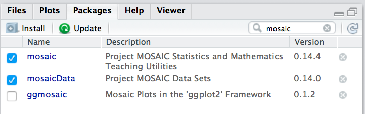

> Nach *jedem* Start von R bzw. RStudio müssen Sie die Erweiterung erneut laden (wenn Sie sie benutzen wollen).

⚠️ Um ein Paket zu laden, muss es installiert sein. Klicken Sie zum Installieren auf den Button “Install” unter dem Reiter “Packages” in RStudio:

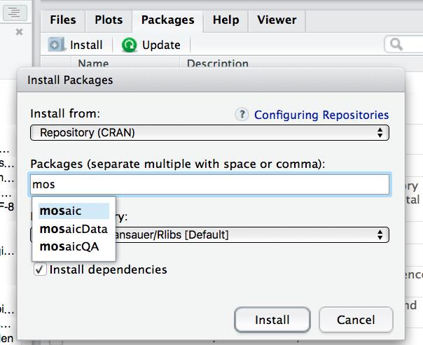

> Sie müssen ein Paket nur *einmal* installieren, um es verwenden zu können. Sie installieren ja auch nicht Ihren Browser jedes Mal neu, wenn Sie den Computer starten.

## 2.4 Daten

Wir verwenden in diesem Kurs diese Datensätze:

- `TeachingRatings`; Sie können ihn [hier](https://sebastiansauer.github.io/data/TeachingRatings.csv) herunterladen (XLSX-Version: https://data-se.netlify.com/download/TR.xlsx).
- `mtcars`; `mtcars` ist schon im Standard-R fest eingebaut; Sie müssen also nichts weiter tun.
- `tips`; den Datensatz `tips` können Sie [hier](https://sebastiansauer.github.io/data/tips.csv) herunterladen.

⚠️ Bitte stellen Sie sicher, dass Sie auf diese Daten zugreifen können während des Kurs. Laden Sie sie vorab herunter.

# 3 Die sieben Schritte der Datenanalyse

> Über siehen Brücken musst du gehen …

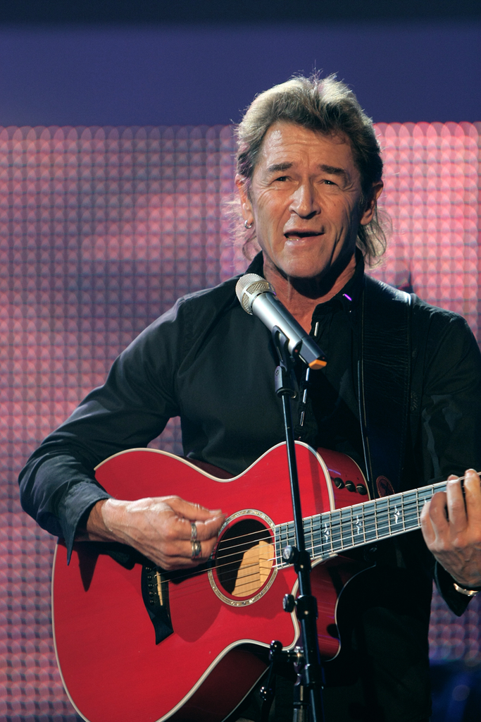

Lizenz: André D Conrad, [CC BY SA 3.0 De](https://de.wikipedia.org/wiki/Peter_Maffay#/media/File:Peter_Maffay.jpg)

Man kann (wenn man will) die Datenanalyse in sieben fünf Brücken oder Schritte einteilen, angelehnt dem Song von Peter Maffay “Über sieben Brücken musst du gehen”. Wir werden nacheinander alle Schritte bearbeiten: Sieben Mal wirst Du die Asche sein. Aber einmal auch der helle Schein.

[figure not shown]

# 4 Arbeiten mit dem Paket `mosaic`

## 4.1 Kringel-Notation (Tilde; Formel-Schreibweise)

Das Paket `mosaic` wird unser Zugpferd für alle folgenden Analysen ein. Es hat den Charme, über eine einfache, konsistente Syntax zu verfügen. Mit wenig kann man da viel erreichen. Genau das, wovon man als Student träumt… (so denken Dozenten, jedenfalls).

Die folgende Syntax

> ```
> Zielbefehl(y ~ x , data=...)
> ```

wird verwendet für

- graphische Zusammenfassungen,
- numerische Zusammenfassungen und
- inferentstatistische Auswertungen

Für Grafiken gilt:

- y: y-Achse Variable
- x: x-Achse Variable

Generell gilt:

`y ~ x`

DAs kann in der Regel gelesen werden **y hängt ab von x**. Die “Kringel-Schreibweise” nennt man in R auch eine “Formel” (formula) oder entsprechend das “formula interface”. Der Kringel (die Tilde) `~` erzeugt sich beim Mac mit `ALT+n` und bei Windows steht es auf einer Taste ziemlich rechts auf der Tastatur. Die Verwendung der Tilde wird auch als “Formel-Schreibweise” (engl. “Formula Interface”) bezeichnet.

# 5 Brücke 1: Daten einlesen

Der einfachste Weg, Daten einzulesen, ist über den Button “Import Dataset” in RStudio. So lassen sich verschiedene Formate - wie XLS(X) oder CSV - importieren.

⚠️ Beim Importieren von CSV-Dateien ist zu beachten, dass R davon von *us-amerikanisch* formatierten CSV-Dateien ausgeht. Was heißt das? Das bedeutet, das Spaltentrennzeichen (engl. delimiter) ist ein Komma `,`. *Deutsch* formatierte CSV-Dateien, wie sie ein deutsch-eingestelltes Excel ausgibt, nutzen aber ein Semikolon `;` (Strichpunkt) als Spaltentrennzeichen.

Haben Sie also eine “deutsche” CSV-Datei, müssen Sie in der Import-Maske von RStudio als *delimiter* ein *semicolon* auswählen.

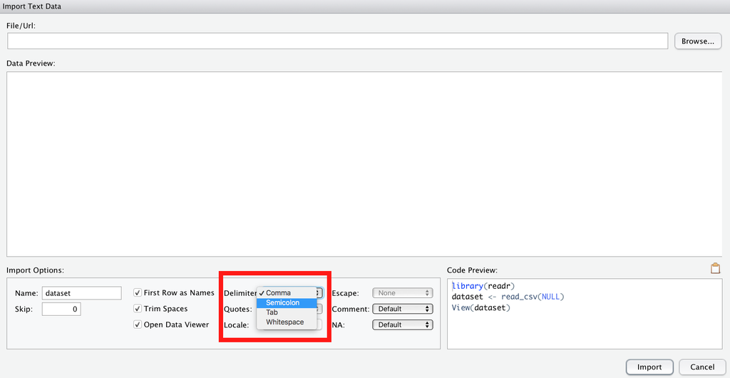

Den TeacherRatings-Datensatz können Sie einfach importieren, indem Sie in der Maske in RStudio den Link `https://data-se.netlify.com/download/TR.csv`[^1] eingeben. Oder per Befehl, geht genauso schnell:

```r
TeachingRatings <- read.csv("https://data-se.netlify.com/download/TR.csv")
```

*Falls* die Datei in Ihrem R-Arbeitsverzeichnis liegt, dann brauchen Sie keinen Pfad angeben:

```r
TeachingRatings <- read.csv("TR.csv")
```

Alternativ können Sie natürlich eine XLS- oder XLSX-Datei importieren (s. https://data-se.netlify.com/download/TR.xlsx); dazu müssen Sie das Paket `readxl` installiert haben. Am einfachsten ist es, XLSX-Dateien zu importieren.

```r
library(readxl)
read_excel("TR.xlsx")
```

```
#> # A tibble: 463 x 12
#>    minority   age gender credits beauty  eval division native tenure students
#>    <chr>    <dbl> <chr>  <chr>    <dbl> <dbl> <chr>    <chr>  <chr>     <dbl>
#>  1 yes         36 female more     0.290   4.3 upper    yes    yes          24
#>  2 no          59 male   more    -0.738   4.5 upper    yes    yes          17
#>  3 no          51 male   more    -0.572   3.7 upper    yes    yes          55
#>  4 no          40 female more    -0.678   4.3 upper    yes    yes          40
#>  5 no          31 female more     1.51    4.4 upper    yes    yes          42
#>  6 no          62 male   more     0.589   4.2 upper    yes    yes         182
#>  7 no          33 female more    -0.126   4   upper    yes    yes          33
#>  8 no          51 female more    -0.258   3.4 upper    yes    yes          25
#>  9 no          33 female more     0.150   4.5 upper    yes    yes          48
#> 10 no          47 male   more     0.541   3.9 upper    yes    no           16
#> # … with 453 more rows, and 2 more variables: allstudents <dbl>, prof <chr>
```

Da aber CSV-Dateien ein Standard heutzutage sind, sollten Sie sich auch mit diesem Datentyp vertraut machen.

## 5.1 tidy data - Tabellen in Normalform

Damit Sie in R vernünftig mit Ihren Daten arbeiten können, sollten die Daten “tidy” sein, d.h. in *Normalform*. Was ist Normalform? Betrachten Sie folgende Abbildung - so sieht eine Tabelle in Normalform aus.

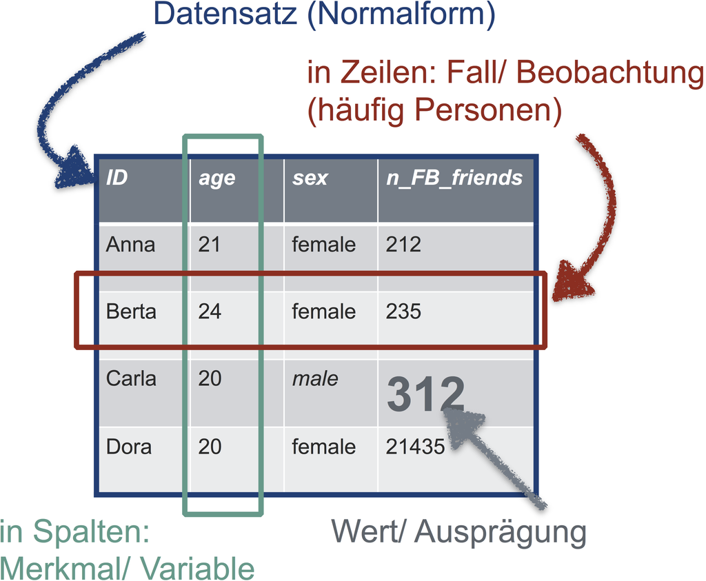

Übrigens heißen Tabellen (mit Spaltennamen) in R *Dataframes*.

Die goldene Regel der Normalform einer Tabelle lautet also:

> In jeder Zeile steht eine Beobachtung (z.B. Person). In jeder Spalte eine Variable (z.B. Geschlecht). In der ersten Zeile stehen die Spaltennamen, danach folgen die Werte. Sonst steht nichts in der Tabelle.

⚠️ Falls Ihre Daten *nicht* in Normalform sind, sollten Sie diese zunächst in Normalform bringen.

💡 Der einfachste Weg (von der Lernkurve her betrachtet, nicht vom Zeitaufwand), Daten in Normalform zu bringen, ist sie in Excel passend umzubauen.

## 5.2 Beispiel für Daten in Nicht-Normalform

Sie denken, dass Ihre Daten immer/auf jeden Fall in Normalform sind? Dann schauen Sie sich mal dieses Bild an:

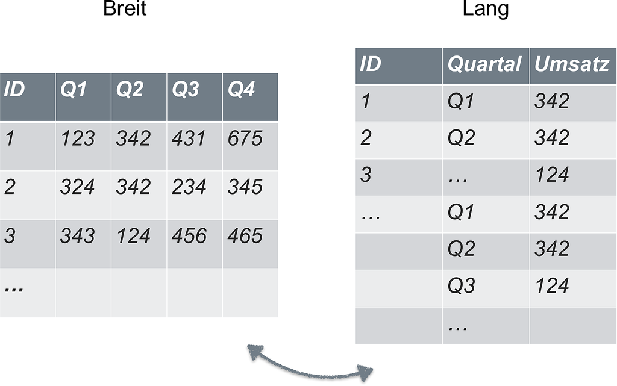

Wir werden in diesem Kurs nicht bearbeiten, wie man Daten von “breit” auf “lang” (=tidy) umformatiert. Aber lesen Sie bei Interesse doch z.B. [hier](https://sebastiansauer.github.io/facial_beauty/) nach.

## 5.3 Daten anschauen

Es empfiehlt sich, zu Beginn einen Blick auf die Daten zu werfen, um zu prüfen, ob alles augenscheinlich seine Richtigkeit hat. Tun Sie das immer, viel Ärger lässt sich so ersparen.

```r
glimpse(TeachingRatings)
```

```
#> Rows: 463
#> Columns: 13
#> $ X           <int> 1, 2, 3, 4, 5, 6, 7, 8, 9, 10, 11, 12, 13, 14, 15, 16, 17…
#> $ minority    <fct> yes, no, no, no, no, no, no, no, no, no, yes, no, no, no,…
#> $ age         <int> 36, 59, 51, 40, 31, 62, 33, 51, 33, 47, 35, 37, 42, 49, 3…
#> $ gender      <fct> female, male, male, female, female, male, female, female,…
#> $ credits     <fct> more, more, more, more, more, more, more, more, more, mor…
#> $ beauty      <dbl> 0.2899, -0.7377, -0.5720, -0.6780, 1.5098, 0.5886, -0.126…
#> $ eval        <dbl> 4.3, 4.5, 3.7, 4.3, 4.4, 4.2, 4.0, 3.4, 4.5, 3.9, 3.1, 4.…
#> $ division    <fct> upper, upper, upper, upper, upper, upper, upper, upper, u…
#> $ native      <fct> yes, yes, yes, yes, yes, yes, yes, yes, yes, yes, no, yes…
#> $ tenure      <fct> yes, yes, yes, yes, yes, yes, yes, yes, yes, no, yes, no,…
#> $ students    <int> 24, 17, 55, 40, 42, 182, 33, 25, 48, 16, 18, 30, 28, 30, …
#> $ allstudents <int> 43, 20, 55, 46, 48, 282, 41, 41, 60, 19, 25, 34, 40, 36, …
#> $ prof        <int> 1, 2, 3, 4, 5, 6, 7, 8, 9, 10, 11, 12, 13, 14, 15, 16, 17…
```

## 5.4 Selber Daten erzeugen

Normalerweise werden Sie Daten in R einlesen, aber manchmal möchte man selber Daten erzeugen. Dazu sollten Sie wissen: Ein Dataframe besteht aus Spalten, wie Sie wissen. Diese Spalten nennt man auch *Vektoren*. Ein Vektor ist eine Sammlung von einzelnen Datenstücken, die hintereinander aufgereiht sind, wie Wäsche an der Wäscheleine. Ach ja, *Vektoren* müssen “sortenrein” sein, also nur Zahlen oder nur Text etc. Um einen Vektor zu erzeugen, benutzt man den Befehle `c` (wie combine oder concatenate, aneinanderfügen):

```r
meine_freunde <- c("Bibi", "Uschi", "Ulf", "Donald der Große")

Deine_PINs <- c(1234, 7777, 1234567, 0000)
```

💻 AUFGABE:

1. Erzeugen Sie einen Vektor mit einem kreativen Namen.
2. Erzeugen Sie einen Vektor, in dem Sie Zahlen und Text mischen. Was passiert?
3. Erstellen Sie einen Vektor aus `meine_freunde` und `Deine_PINs`. Was passiert?
4. Adeln Sie mal Ihren Vektor zu einer waschechten Tabelle (Dataframe) mit dem Befehl `data.frame(vektor)`; nicht vergessen, der resultierenden Tabelle einen Namen zu geben bzw. eine neue Tabelle zu benennen, die das Ergebnis des Befehle `data.frame` speichert.

## 5.5 Daten als CSV oder Excel exportieren

Wie kriege ich die Daten aus R wieder raus? Was ist sozusagen mit REXIT-Strategie? Keine Sorge, die Straße fährt in beide Richtungen. Sagen wir, Sie möchten den Dataframe `TeachingRatings` exportieren, um außerhalb von R damit Kunststücke zu vollbringen:

```r
write.csv(TeachingRatings, "TeachingRatings.csv")

write.xlsx(TeachingRatings, "TeachingRatings.xlsx")
```

Dieser Befehl (`write.xlsx`) schreibt eine XLSX-Datei in das aktuelle R-Verzeichnis (das Arbeitsverzeichnis).

## 5.6 Das R-Arbeitsverzeichnis

💡 R schreibt Dateien immer in das R-Arbeitsverzeichnis. Das R-Arbeitsverzeichnis ist das Arbeitsverzeichnis, das R als Standard annimmt. Wenn Sie zu R etwas sagen wie “lade daten.csv!”, dann wird R in dem Ordner nach schauen, der als Arbeitsverzeichnis ausgewählt ist.

Mit `getwd()` findet man heraus, was das aktuelle Arbeitsverzeichnis ist:

```r
getwd()
```

```
#> [1] "/Users/sebastiansaueruser/Documents/Lehre/Statistik/r-crashkurse"
```

Mit `set.wd()` kann man ein Arbeitsverzeichnis wählen. Alternativ geht das auch über das Menü *Session > Set Working Directory > Choose Directory …*.

💻 AUFGABE:

1. Finden Sie Ihr aktuelles Arbeitsverzeichnis heraus.
2. Setzen Sie Ihr Arbeitsverzeichnis auf den Ordner, in dem Ihre Lieblings-Skriptdatei liegt.

## 5.7 Textkodierung in UTF-8

Falls Sie RStudio oder ein beliebiger Texteditor irgendwann fragt, wie die Textdatei kodiert sein soll, wählen Sie immer “UTF-8”. UTF-8 ist eine Kodierungstabelle, so dass der Computer weiß, welcher Buchstabe welcher Bitfolge zugeordnet ist; dabei ist UTF-8 so großzügig geplant, dass alle möglichen Sonderzeichen (Deutsch, Chinesisch, Hebräisch…) dazu passen. UTF-8 ist die Standard-Kodierung für Textdateien im Internet. Falls R-Studio Sie nach “Save with Encoding” fragt, wählen Sie immer UTF-8. Speichern Sie Ihre Skriptdateien am besten immer in diesem Format. Etwas mehr zur Textkodierung finden Sie bei Sauer (2019) oder hier.

💡 In RStudio kann man unter `File..Save with Encoding...` die Textcodierung einstellen.

💻 AUFGABE:

1. Prüfen Sie, in welchem Format Ihr Dokument kodiert ist.
2. Setzen Sie das Format ggf. auf UTF-8.

# 6 Schritt 2: Aufbereiten

Der Schritt des Aufbereitens ist häufig der zeitintensivste Schritt. In diesem Schritt erledigen Sie alles, bevor Sie zu den “coolen” oder fortgeschrittenen Analysen kommen. Z.B.

- prüfen auf Fehler beim Daten einlesen (und korrigieren)
- Spaltennamen korrigieren
- Daten umkodieren
- Fehlende Werte verarzten
- Komische Werte prüfen
- Daten zusammenfassen
- Zeilenmittelwerte bilden
- Logische Variablen bilden
- …

## 6.1 Auf Fehler prüfen beim Einlesen

⚠️ Ein häufiger Fehler ist, dass die Daten nicht richtig eingelesen werden. Zum Beispiel werden die Spaltentrennzeichen nicht richtig erkannt. Das kann dann so aussehen:

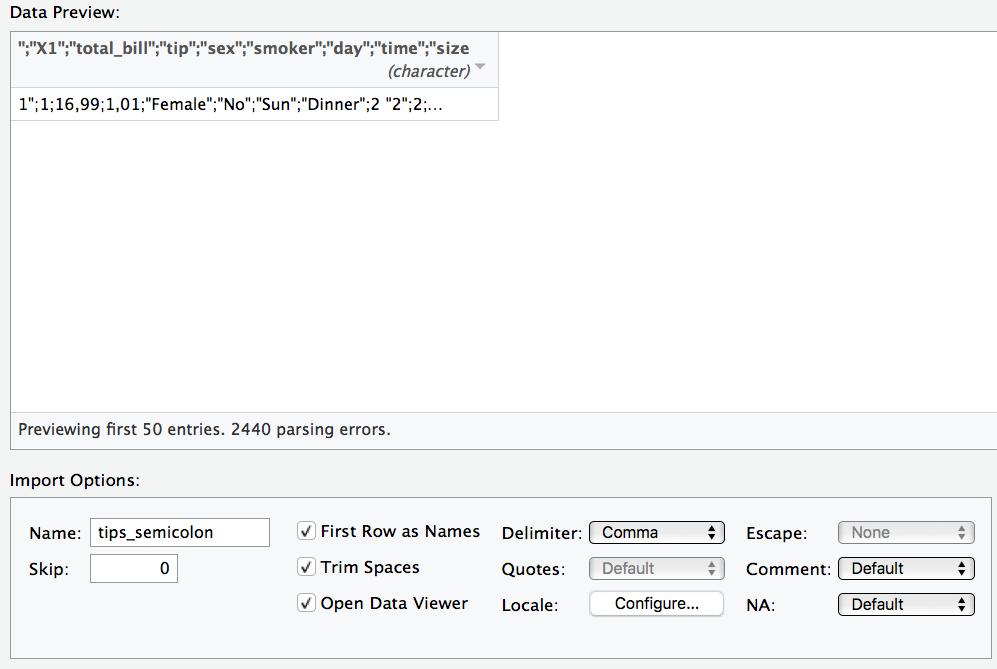

Unter “delimiter” in der Maske können Sie das Trennzeichen anpassen.

⚠️ “Deutsche” CSV-Dateien verwenden als *Dezimaltrennzeichen* ein Komma; englisch-formatierte CSV-Dateien hingegen einen Punk. R geht per Default von englisch-formatierten CSV-Dateien aus. Importieren Sie eine deutsch-formatierte CSV-Datei, müssen Sie das Dezimaltrennzeichen von Hand ändern; es wird nicht automatisch erkannt.

💡 Unter “locale” können Sie das Dezimaltrennzeichen ggf. anpassen.

## 6.2 Spaltennamen korrigieren

Spaltennamen müssen auch “tidy” sein. Das heißt in diesem Fall:

- keine Leerzeichen
- keine Sonderzeichen (#,ß,ä,…)
- nicht zu lang, aber trotzdem informativ

> Spaltennamen sollten nur Buchstaben (ohne Umlaute) und Ziffern enthalten und mit Buchstaben beginnen. Für Textdaten in den Spalten sind diese Regeln auch sinnvoll.

💡 Am einfachsten ändern Sie die Spaltennamen in Excel.

In R können Sie Spaltennamen z.B. so ändern:

```r
rename(TeachingRatings, festangestellt = tenure) -> TR2
```

In Pseudo-R könnte man schreiben:

```
benenne_spalte_um(meine_tabelle,
                  neuer_name = altername) ->
  meine_neue_tabelle
```

Der R-Zufweisungspfeil `<-` bzw. `->` funktioniert in beide Richtungen; er darf nach links oder rechts zeigen. In jedem Fall wird das Objekt, auf das er zeigt, “befüllt” mit den Inhalten die auf der anderen Seite stehen.

💻 AUFGABE:

- Benennen Sie in `TeachingRatings` die Spalte `native` in `Muttersprachler` um; speichern Sie aber das Ergebnis in einem neuen Dataframe.
- Suchen Sie sich noch zwei weitere Spalten, und benennen Sie die Spaltennamen nach eigenen Vorstellungen um!

## 6.3 Umkodieren

Gerade bei der Analyse von Fragebogendaten ist es immer wieder nötig, Daten umzukodieren. Klassisches Beispiel: Ein Item ist negativ kodiert. Zum Beispiel das Item “Ich bin ein Couch-Potator” in einem Fragebogen für Extraversion.

Nehmen wir an, das Item “i04” hat die Werte 1 (“stimme überhaupt nicht zu”) bis 4 (“stimme voll und ganz zu”). Kreuzt jemand das Couch-Potato-Item mit 4 an, so sollte er nicht die maximale Extraversion-Punktzahl (4), sondern die *minimale* Extraversion-Punktzahl (1) erhalten. Also

` 1 –> 4

2 –> 3

3 –> 2

4 –> 1 `

Am einfachsten ist dies zu bewerkstelligen mit folgendem R-Befehl aus dem Paket `sjmisc`.

Zuerst erzeugen wir uns *ganzzahlige* Evaluationswerte:

```r
TeachingRatings <- mutate(TeachingRatings, eval_rounded = round(eval))
tally(~ eval_rounded, data = TeachingRatings)
```

```
#> eval_rounded
#>   2   3   4   5
#>   4  73 307  79
```

Das war die Vorbereitung; jetzt das eigentliche Umkodieren:

```r
TeachingRatings <- rec(TeachingRatings, eval_rounded, rec = "2=5; 3=4; 4=3; 5=2")
```

| X | eval | eval_rounded | eval_rounded_r |
| --- | --- | --- | --- |
| 1 | 4.3 | 4 | 3 |
| 2 | 4.5 | 4 | 3 |
| 3 | 3.7 | 4 | 3 |
| 4 | 4.3 | 4 | 3 |
| 5 | 4.4 | 4 | 3 |

## 6.4 Fehlende Werte

Der einfachste Umgang mit fehlenden Werten ist: nichts machen. Denken Sie nur daran, dass viele R-Befehle von Natur aus nervös sind - beim Anblick von fehlenden Werten werden sie panisch und machen nix mehr. Strecken alle Viere von sich. Der einfachste Weg ist, Zeilen mit fehlenden Werten (in den betreffenden Spalten) zu entfernen. Das geht zum Beispiel mit `drop_na()` aus `tidyverse`[^2]:

```r
mein_bereinigter_dataframe <- drop_na(mein_dataframe,
                                      spalte1, spalte2)
```

Dieser Befehl löscht alle Zeilen mit fehlenden Werten aus der Tabelle[^3] `mein_dataframe`, sofern sie sich in den Spalten `spalte1` und `spalte2` befinden (Sie können beliebig viele Spalten anführen; einfach mit Komma trennen. Geben Sie keine Spalten an, so werden alle Spalten nach fehlenden Werten durchsucht). Das Ergebnis ist eine Tabelle ohne fehlende Werte in den Spalten `spalte1` und `spalte2`; wir speichern es als neue Tabelle mit Namen `mein_bereinigter_dataframe`.

Alternativ kann man einzelnen Befehlen, wie `mean()` sagen, dass sie fehlende Werte ignorieren sollen. Haben sie fehlende Werte in ihrer Tabelle, so verwenden Sie den Parameter `na.rm = TRUE`. `na` steht für “not available”, also fehlende Werte. `rm` steht für “remove”. Also `mean(~ i04_r, data = meine_tabelle, na.rm = TRUE)`. Leider ist die genaue Schreibweise nicht immer die gleiche; hier die wichtigsten Befehle mit dem Parameter, der sei auch bei fehlenden Werten wieder zurück zur Arbeit bringt:

```r
mean(~ eval, data = TeachingRatings,
     na.rm = TRUE)
```

```
#> [1] 4
```

```r
# für sd, median etc. genauso

cor(eval ~ beauty, data = TeachingRatings,
    use = "complete.obs")
```

```
#> [1] 0.189
```

💡 Der R-Befehl `inspect` aus `mosaic` zeigt Ihnen an, ob es fehlende Werte gibt: `inspect(meine_daten)`.

💻 AUFGABE:

- Prüfen Sie, ob es im Datensatz `TeachingRatings` fehlende Werte gibt.
- Prüfen Sie, ob es im Datensatz `mtcars` fehlende Werte gibt.

## 6.5 Komische Werte

Hat ein Spaßvogel beim Alter 999 oder -1 angegeben, kann das Ihre Daten ganz schön verhageln. Prüfen Sie die Daten auf komische Werte. Der einfachste Weg ist, sich die Daten in Excel anzuschauen. Cleverer ist noch, sich Zusammenfassungen auszugeben, wie der kleinste oder der größte Wert, oder der Mittelwert etc., und dann zu schauen, ob einem etwas spanisch vorkommt. Diagramme sind ebenfalls hilfreich. Dann ändern Sie die Werte in Excel und laden die Daten erneut ins R.

## 6.6 Logische Variablen bilden

```r
TeachingRatings <- TeachingRatings %>%
  mutate(Traumdozent = beauty > 1)
```

```r
prop(~Traumdozent, data = TeachingRatings)
```

```
#> prop_TRUE
#>     0.145
```

Ok, etwa 15% der Dozenten sind so hübsch. Erzeugen wir einen Teil-Datensatz nur mit diesen Dozentenmodells:

```r
Dozimodels <- filter(TeachingRatings, Traumdozent == TRUE)
glimpse(Dozimodels)
inspect(Dozimodels)
```

💻 AUFGABE:

- Erstellen Sie eine Variable `Asbach`, definiert als `TRUE`, wenn `age < 70`.
- Erstellen Sie eine Variable `keiner_mag_mich`, definiert als TRUE, wenn `eval <= 2`.
- Denken Sie sich noch selber mindestens ein Beispiel aus.

## 6.7 Daten univariat zusammenfassen

Deskriptive Statistik ist letztlich nichts anderes, als Daten geschickt zusammenzufassen. Praktisch wird meistens eine Spalte einer Tabelle zu einer Zahl zusammengefasst.

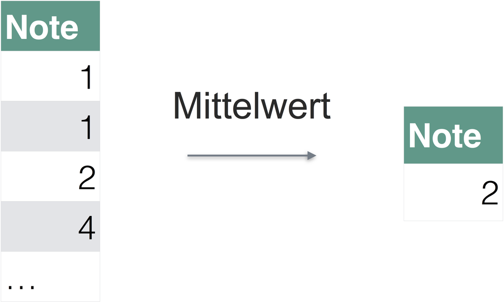

```r
inspect(TeachingRatings)
```

```
#>
#> categorical variables:
#>          name   class levels   n missing
#> 1    minority  factor      2 463       0
#> 2      gender  factor      2 463       0
#> 3     credits  factor      2 463       0
#> 4    division  factor      2 463       0
#> 5      native  factor      2 463       0
#> 6      tenure  factor      2 463       0
#> 7 Traumdozent logical      2 463       0
#>                                    distribution
#> 1 no (86.2%), yes (13.8%)
#> 2 male (57.9%), female (42.1%)
#> 3 more (94.2%), single (5.8%)
#> 4 upper (66.1%), lower (33.9%)
```

[output cut: 25 more lines]

💡 mit `help(Befehl)` bekommt man Hilfe zu einem Befehl oder einem sonstigen Objekt (z.B. Datensatz).

### 6.7.1 Numerische Variablen mit `favstats` untersuchen

Ein einfacher, um Deskriptivstatistik für eine *numerische Variable* auf einen Abwasch zu erledigen ist der Befehl `favstats` aus dem Paket `mosaic` (vorher laden nicht vergessen):

```r
favstats(~ eval, data = TeachingRatings)
```

```
#>  min  Q1 median  Q3 max mean    sd   n missing
#>  2.1 3.6      4 4.4   5    4 0.555 463       0
```

Der Befehl `favstats` lässt auch Subgruppenanalysen zu, z.B. um Männer und Frauen zu vergleichen:

```r
favstats(eval ~ gender, data = TeachingRatings)
```

```
#>   gender min  Q1 median  Q3 max mean    sd   n missing
#> 1 female 2.3 3.6   3.90 4.3 4.9 3.90 0.539 195       0
#> 2   male 2.1 3.7   4.15 4.5 5.0 4.07 0.557 268       0
```

> `favstats` ist sehr praktisch, weil Sie mit einem Befehl sehr viele Informationen bekommen, sogar Subgruppenanalysen sind möglich. Es lohnt sich für Sie, sich diesen Befehl gut zu merken.

💻 AUFGABE:

- Was sind wichtige Lagemaße für `beauty``?
- Was sind wichtige Streuungsmaße für `eval`?
- Welches Skalenniveau hat `minority`? Für den Fall, dass `minority` nicht metrisch ist (also kategorial), macht es dann Sinn, Mittelwert oder SD zu berechnen?

### 6.7.2 Typische Deskriptive Statistiken

Die üblichen Verdächtigen der deskriptiven Statistiken lassen sich leicht aus Ihrem Versteck hervorlocken:

```r
mean(eval~gender, data = TeachingRatings)
```

```
#> female   male
#>   3.90   4.07
```

```r
median(eval~gender, data = TeachingRatings)
```

```
#> female   male
#>   3.90   4.15
```

```r
sd(eval~gender, data = TeachingRatings)
```

```
#> female   male
#>  0.539  0.557
```

```r
var(eval~gender, data = TeachingRatings)
```

```
#> female   male
#>   0.29   0.31
```

```r
IQR(eval~gender, data = TeachingRatings)
```

```
#> female   male
#>    0.7    0.8
```

```r
diffmean(eval~gender, data = TeachingRatings)
```

```
#> diffmean
#>    0.168
```

```r
min(eval~gender, data = TeachingRatings)
```

```
#> female   male
#>    2.3    2.1
```

```r
max(eval~gender, data = TeachingRatings)
```

```
#> female   male
#>    4.9    5.0
```

Aber mit `favstats()` geht es meist einfacher. Die Differenz zweier Mediane bekommt man so:

```r
diff(median(eval ~ gender, data = TeachingRatings))
```

```
#> male
#> 0.25
```

⚠️ Alle diese Befehle sind etwas … nervös. Fehlt in den entsprechenden untersuchten Tabellen nur ein Wert, so legen diese Befehle die Arbeit nieder. Die Begründung lautet, Sie sollen auf das Problem hingewiesen werden. Über diese Logik kann man streiten; möchten Sie die Befehle zum Arbeiten bringen, auch wenn einige Daten fehlen sollten, dann fügen Sie diesen Parameter hinzu: `na.rm = TRUE`.

Sinngemäß übersetzt: “Hey R, wenn Du NAs triffst (fehlende Werte), dann ‘remove’ (ignoriere) diese. Ja, genauso (TRUE) ist es!”

```r
mean(eval~gender, data = TeachingRatings, na.rm = TRUE)
```

```
#> female   male
#>   3.90   4.07
```

### 6.7.3 Nominale Variablen

Eine Häufigkeitstabelle für eine *nicht-metrische* Variable lässt über den Befehl `tally` erstellen.

Mit dem Befehl `summary(meine_tabelle)` bekommt man schon eine brauchbare Übersicht für nominale (kategoriale) Variablen. Man kann aber auch den Befehl `tally` verwenden, um sich Häufigkeit auszählen zu lassen:

```r
tally(~gender, data = TeachingRatings)
```

```
#> gender
#> female   male
#>    195    268
```

Ach ja, der `inspect`er sagt das ja auch:

```r
inspect(TeachingRatings)
```

```
#>
#> categorical variables:
#>          name   class levels   n missing
#> 1    minority  factor      2 463       0
#> 2      gender  factor      2 463       0
#> 3     credits  factor      2 463       0
#> 4    division  factor      2 463       0
#> 5      native  factor      2 463       0
#> 6      tenure  factor      2 463       0
#> 7 Traumdozent logical      2 463       0
#>                                    distribution
#> 1 no (86.2%), yes (13.8%)
#> 2 male (57.9%), female (42.1%)
#> 3 more (94.2%), single (5.8%)
#> 4 upper (66.1%), lower (33.9%)
```

[output cut: 25 more lines]

Allerdings kann `tally` auch über mehrere Variablen auszählen:

```r
tally(tenure~gender, data = TeachingRatings)
```

```
#>       gender
#> tenure female male
#>    no      50   52
#>    yes    145  216
```

```r
tally(~gender, data = TeachingRatings)
```

```
#> gender
#> female   male
#>    195    268
```

Und Anteilsunterschiede mit `diffprop()`:

```r
diffprop(tenure~gender, data = TeachingRatings)
```

```
#> diffprop
#>  -0.0624
```

### 6.7.4 Vertiefung: Nicht-NA-nervöse R-Befehle

Sie sind genervt von der vorsichtigen Art einiger R-Befehle, auf fehlende Werte zu reagieren? Es gibt einige R-Befehle, die angesichts fehlender Werte (NA) *nicht* nervös werden. Es folgen einige Beispiele.

Erzeugen wir zuerst einen fehlenden Wert zu Demonstrationszwecken:

```r
TeachingRatings$eval[1] <- NA
TeachingRatings$gender[1] <- NA
head(TeachingRatings$eval)
```

```
#> [1]  NA 4.5 3.7 4.3 4.4 4.2
```

Mit diesem Befehl haben wir das erste Element der Spalten `eval` und `gender` auf NA gesetzt, d.h. als fehlend deklariert (gelöscht). `head()` zeigt die ersten paar Werte eines Objekts an (hier für einen kurzen Check angewendet).

```r
library(sjmisc)

descr(TeachingRatings, eval, beauty)
```

```
#>
#> ## Basic descriptive statistics
#>
#>     var    type  label   n NA.prc mean   sd   se    md trimmed
#>    eval numeric   eval 462   0.22    4 0.56 0.03  4.00    4.03
#>  beauty numeric beauty 463   0.00    0 0.79 0.04 -0.07   -0.05
#>              range iqr  skew
#>        2.9 (2.1-5) 0.8 -0.46
#>  3.42 (-1.45-1.97) 1.2  0.52
```

```r
frq(TeachingRatings, gender)
```

```
#>
#> gender <categorical>
#> # total N=463  valid N=462  mean=1.58  sd=0.49
#>
#> Value  |   N | Raw % | Valid % | Cum. %
#> ---------------------------------------
#> female | 194 | 41.90 |   41.99 |  41.99
#> male   | 268 | 57.88 |   58.01 | 100.00
#> <NA>   |   1 |  0.22 |    <NA> |   <NA>
```

Die Befehle `descr()` und `frq()` aus dem Paket `sjmisc` sind im Standard so eingestellt, dass er Ergebnisse berechnet, auch wenn fehlende Werte vorliegen.

Für nicht-nervöse Berechnung von Korrelationen bietet sich das Paket `corrr` an; dort gibt es einen Befehl `correlate()` der eine Korrelationsmatrix erzeugt, die paarweise fehlende Daten bei der Berechnung ingoriert:

```r
library(corrr)

TeachingRatings %>%
  select(eval, beauty, age) %>%
  correlate()
```

```
#> # A tibble: 3 x 4
#>   rowname    eval beauty     age
#>   <chr>     <dbl>  <dbl>   <dbl>
#> 1 eval    NA       0.189 -0.0503
#> 2 beauty   0.189  NA     -0.298
#> 3 age     -0.0503 -0.298 NA
```

## 6.8 Zeilenmittelwerte bilden

Bei Umfragen kommt es häufig vor, dass man Zeilenmittelwerte bildet. Wieso? Man möchte z.B. in einer Mitarbeiterbefragung den “Engagementwert” jedes Beschäftigten wissen (klingt einfach gut). Dazu addiert man die Werte jedes passenden Items auf. Diese Summe teilen Sie durch die Anzahl der Spalten

💡 Zeilenmittelwerte kann man übrigens auch mit Excel bilden …

In R gibt es im Paket `sjmisc` einen komfortablen Befehl, `row_means()`. Das Ergebnis sieht man in Tabelle 6.1.

```r
TeachingRatings <- row_means(TeachingRatings,
                             age, eval, beauty,  # aufzusummierende Spalten
                             n = .9,
                             var  = "Zeilenmittel")
```

Der Parameter `n` gibt den Mindestanteil nicht-fehlender Daten an (hier: 90%), damit ein Zeilenmittelwert berechnet wird. Mit `var` geben wir einen Namen für neue Spalte des Zeilenmittelwerts an.

Tabelle 6.1: Zeilenmittelwerte bilden

| age | eval | beauty | Zeilenmittel |
| --- | --- | --- | --- |
| 36 | NA | 0.290 | NA |
| 59 | 4.5 | -0.738 | 20.9 |
| 51 | 3.7 | -0.572 | 18.0 |
| 40 | 4.3 | -0.678 | 14.5 |
| 31 | 4.4 | 1.510 | 12.3 |

Der Befehl `row_sums()` leistet Ähnliches für Summen- anstatt für Mittelwerte.

## 6.9 Daten bivariat zusammenfassen

### 6.9.1 Korrelation (nach Pearson)

```r
cor(eval ~ beauty, data = TeachingRatings)
```

Falls Sie viele Variablen auf ihre Korrelation untersuchen wollen, können Sie es so auf einen Abwasch tun:

```r
TR2 <- dplyr::select(TeachingRatings, eval, beauty, age)
cor(TR2)
```

```
#>        eval beauty    age
#> eval      1     NA     NA
#> beauty   NA  1.000 -0.298
#> age      NA -0.298  1.000
```

💡 Manchmal gibt’s zwei Häuser, in denen “Herr Maier” wohnt. Um klar zu machen, *welchen* Maier Sie meinen, empfiehlt es sich, die Adresse mit anzugeben. In R ist es analog: Manchmal gibt es zwei Pakete, in denen ein Befehl mit gleichem Namen (z.B. `select`) wohnt. Mit dem Operator `::` gibt man an, aus welchem Paket man den Befehl ziehen möchte.

Eine ganz ansprechende Visualisierung bekommt man so:

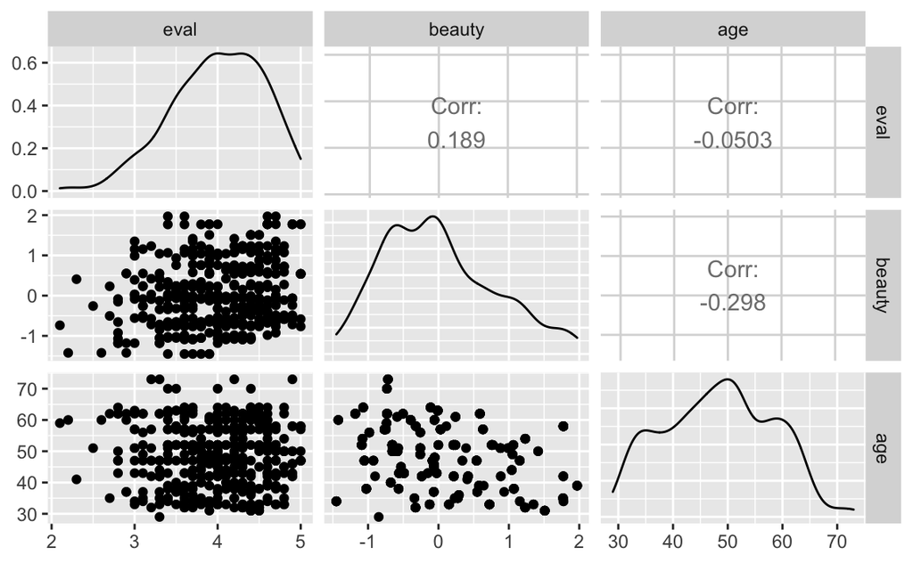

```r
ggpairs(TR2)
```

### 6.9.2 Zusammenhang zweier nominaler Variablen

Ob es wohl bei Männern (Frauen) mehr Angehörige einer ethnischen Minderheit gibt? Mit anderen Worten: Hängen die Variablen *Minderheit* (‘minority’) und *Geschlecht* (`sex`) zusammen?

Ein einfaches Maß hierzu ist der Unterschied in den Anteilen; dieses Maß kann man nur einsetzen, wenn man zwei Gruppen (z.B. Frauen und Männer) vergleicht, wenn man also binäre Variablen vergleicht.

```r
diffprop(minority ~ gender, data = TeachingRatings)
```

```
#> diffprop
#>   0.0759
```

Je größer der (absolute) Wert, desto stärker der Zusammenhang bzw. der Effekt.

Überprüft man den Zusammenhang von nicht-binären nominalen Variablen, so kann man den $\chi^2$-Wert als Effektgröße heranziehen; dieses Maß ist allerdings abhängig von der Stichprobengröße.

## 6.10 Zeilen filtern

Ist man daran interessiert, nur einen Teil der Fälle (=Zeilen) auszuwerten, so hilft der Befehl `filter` weiter; `filter` wird über das Paket `tidyverse` geladen.

```r
filter(TeachingRatings, gender == "male") -> dozi_maenner
```

💻 AUFGABE:

- Erstellen Sie eine Tabelle mit festangestellten Dozenten !
- Erstellen Sie eine Tabelle nur mit gut aussehenden Dozenten (der genaue Wert bleibt Ihnen überlassen).

## 6.11 Spalten auswählen

Manchmal hat meine “breite” Tabelle, also viele Spalten. Da hilft Abspecken, um die Sachlage übersichtlicher zu machen. Sprich: Nur ein paar wichtige Spalten auswählen, die anderen unter den Tisch fallen lassen.

Das kann man mit dem Befehl `select` (engl. auswählen) erreichen, der über das Paket `tidyverse` geladen wird:

```r
select(TeachingRatings, eval, beauty) -> TR2
```

Der Befehl kann noch ein paar Tricks, die man z.B. [hier](https://sebastiansauer.github.io/Praxis_der_Datenanalyse/datenjudo.html#spalten-wahlen-mit-select) nachlesen kann.

💻 AUFGABE:

- Erstellen Sie eine Tabelle nur mit `gender` und `tenure`. Dann wenden Sie `tally` darauf an.
- Wenden Sie dann die Befehle `rowSums` und `rowMeans` auf eine andere von Ihnen erstellten “Mini-Tabelle” an. Speichern Sie das Ergebnis von `rowSums` als neue Spalte von `TeachingRatings`.

## 6.12 Spalten einer Tabelle sortieren

Bestimmt haben Sie schon mal in Excel eine Spalte sortiert, z.B. so, dass die großen Eurowerte ganz oben standen. In R kann man das mit dem Befehl `arrange` (via `tidyverse`) erreichen:

```r
arrange(TeachingRatings, -eval) %>% head
```

Der Befehl `%>% head` bedeutet nur “UND DANN (das ist das %>%) zeige den Kopf (den Beginn) von dem, was Du gerade gemacht (sortiert) hast”.

💻 AUFGABE:

- Sortieren Sie `TeachingRatings` nach Schönheit!
- Sortieren Sie `TeachingRatings` nach Bewertungsergebnis! Sortieren Sie `TeachingRatings` *gleichzeitig* nach Schönheit und Bewertungsergebnis! (Tipp: `arrange(tabelle, spalte1, spalte2)`).

# 7 Schritt 3: Visualisieren

Ein Bild sagt bekanntlich mehr als 1000 Worte. Betrachten Sie dazu “Anscombes Quartett”:

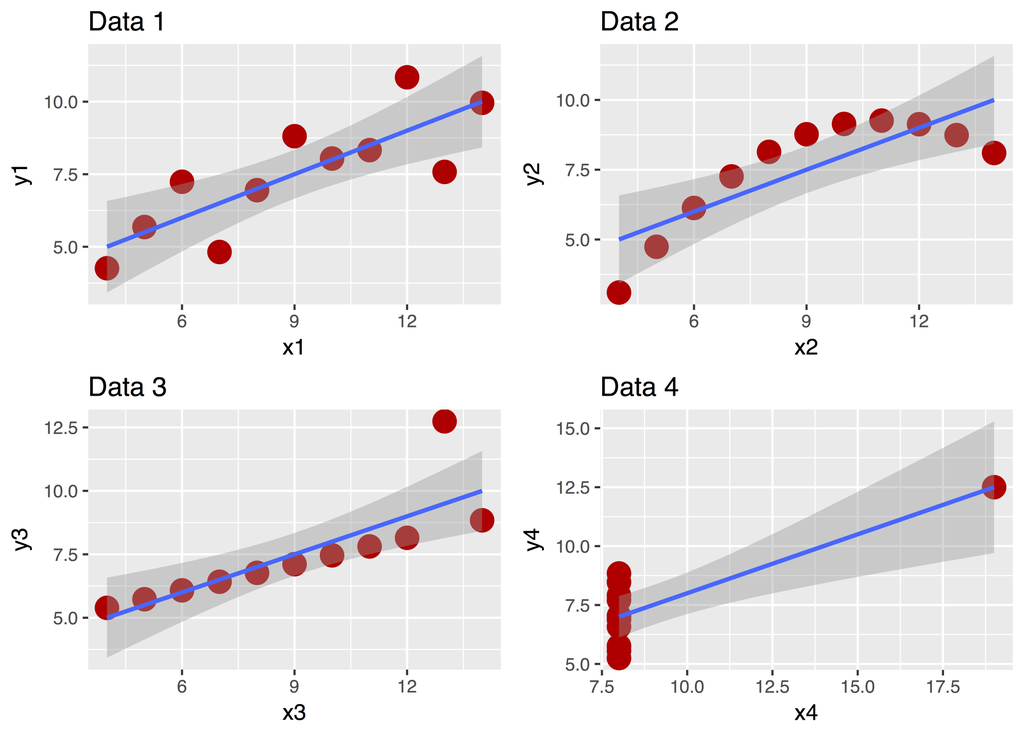

Diese vier Datensätze sehen ganz unterschiedlich aus, nicht wahr? Aber ihre zentralen deskriptiven Statistiken sind praktisch gleich! Ohne Diagramm wäre uns diese Unterschiedlichkeit nicht (so leicht) aufgefallen!

Zur Visualisierung empfehle ich das R-Paket `ggforumla`. Hinter den Kulissen wir dem verbreiteten Visualiserungspaket `ggplot2` die Denkweise von `mosaic` eingeimpft. Der Hauptbefehl lautet `gf_XXX`, wobei `XXX` für eine bestimmte Art (Geom) von Diagramm steht, also z.B. ein Histogramm oder ein Boxplot.

## 7.1 Syntax von `gf_XXX`

Die normale Denkweise von `mosaic` wird verwendet:

`gf_diagrammtyp(Y_Achse ~ X_Achse, sonstiges, data = meine_daten)`.

`gf_` steht für `ggplot` und `formula`.

Darüber hinaus verkraftet der Befehl noch viele andere Schnörkel, die wir uns hier sparen. Interessierte können googeln… Es ist ein sehr mächtiger Befehl, der sehr ansprechende Diagramme erzeugen kann.

Probieren wir’s!

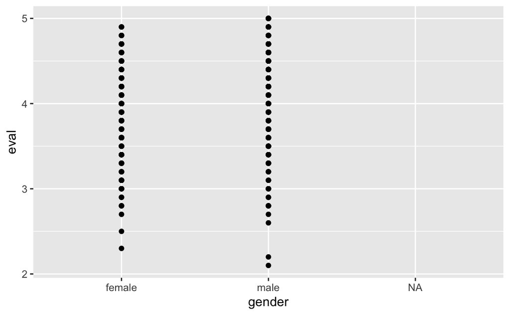

```r
data(mtcars)
gf_point(eval ~ gender, data = TeachingRatings)
```

Easy, oder?[^5]

Ein anderes Geom:

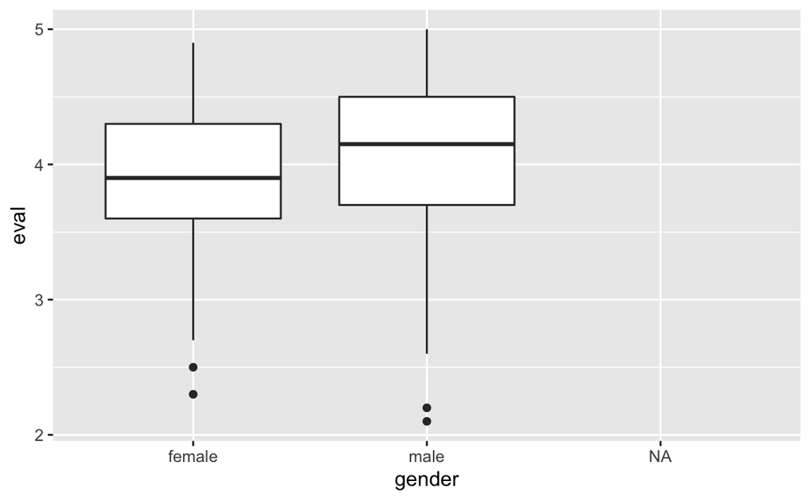

```r
gf_boxplot(eval ~ gender, data = TeachingRatings)
```

⚠️ Beachten Sie, dass nur dann *mehrere Boxplots* gezeichnet werden, wenn auf der X-Achse eine nominal skalierte Variable steht.

Oder mal nur *eine* Variable (ihre Verteilung) malen:

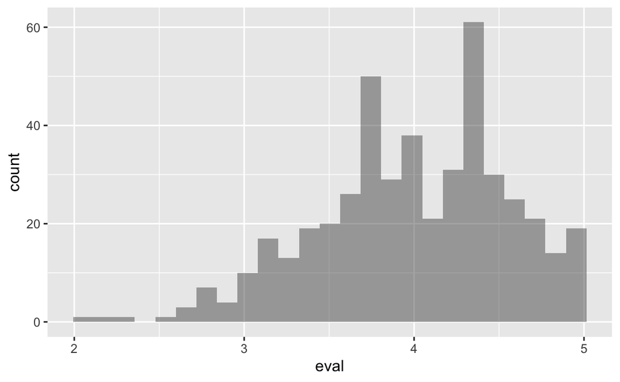

```r
gf_histogram(~eval, data = TeachingRatings)
```

💡 Geben wir keine Y-Variable an, nimmt R eigenständig die Häufigkeit pro X-Wert!

## 7.2 Jittern

Probieren Sie mal diesen Befehl:

```r
gf_point(eval ~ gender, data = TeachingRatings)
```

Was nicht so schön bei diesem Diagramm ist, ist, dass viele Punkte sich gegenseitig überdecken. Dieses Überdecken bezeichnet man auch als “Overplotting” (hört sich cooler an). Besser wäre es, wenn sich die Punkte nicht überdecken würden, dann würde man besser erkennen, wie viele Punkte wo liegen. Eine einfache Lösung bestünde darin, das Bild etwas zu “schütteln” oder zu “wackeln”, so dass die Punkte etwas verwackelt würden und damit nebeneinander zu liegen kämen. Das kann mit man mit dem Geom `jitter` (eng. für wackeln) erreichen:

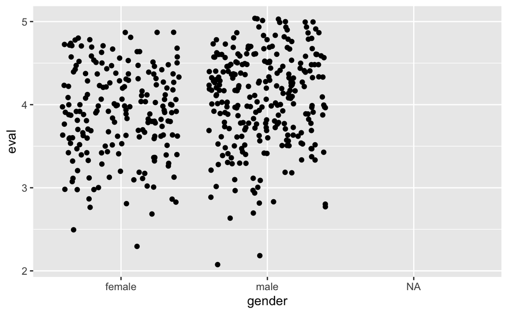

```r
gf_jitter(eval ~ gender, data = TeachingRatings)
```

Möchte man die Punkte etwas enger haben, so kann man den Parameter `width` hinzufügen:

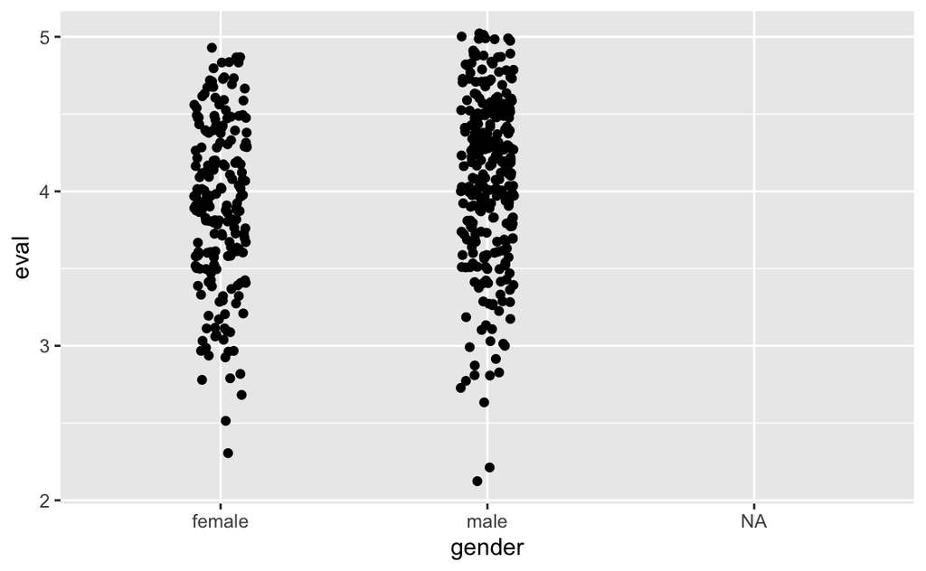

```r
gf_jitter(eval ~ gender, data = TeachingRatings, width = .1)
```

💡 Die Reihenfolge der Parameter in einem R-Befehl ist egal, solange man die Parameter benennt (width, data,…).

💻 AUFGABE:

- Tauschen Sie mal “histogram” mit “density”!
- Erstellen Sie ein Histogramm für `beauty`!
- Erstellen Sie Boxplots für `beauty`, vergleichen Sie dabei Männer und Frauen (Tipp: `gender` steht auf der X-Achse).
- Erstellen Sie Boxplots für `eval`, vergleichen Sie dabei die überdurchschnittlich schöne mit unterdurchschnittlichen schönen.

## 7.3 Plot, um Mittelwerte darzustellen

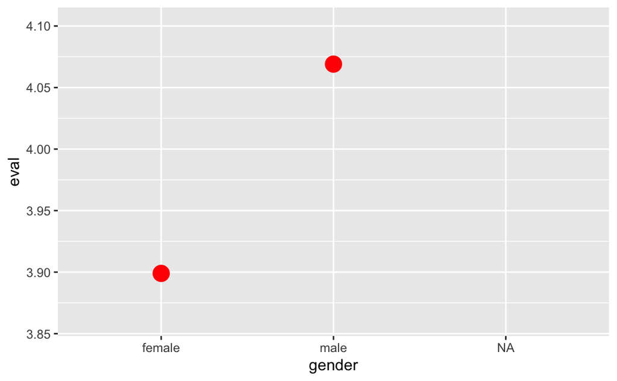

```r
gf_point(eval ~ gender,
         data = TeachingRatings,
         stat = "summary",
         color = "red",
         size = 5)
```

Überprüfen wir mal, ob die Punkte beim Mittelwert liegen:

```r
mean(eval ~ gender, data = TeachingRatings)
```

```
#> female   male
#>   3.90   4.07
```

😄.

Wir können auch mehrere Gruppen in “Teil-Bildchen” vergleichen, dazu nehmen wir den Operator `|`; das kann man sich gut merken, wenn man sich vorstellt, dieser vertikale Strich grenzt das linke vom rechten Bild ab:

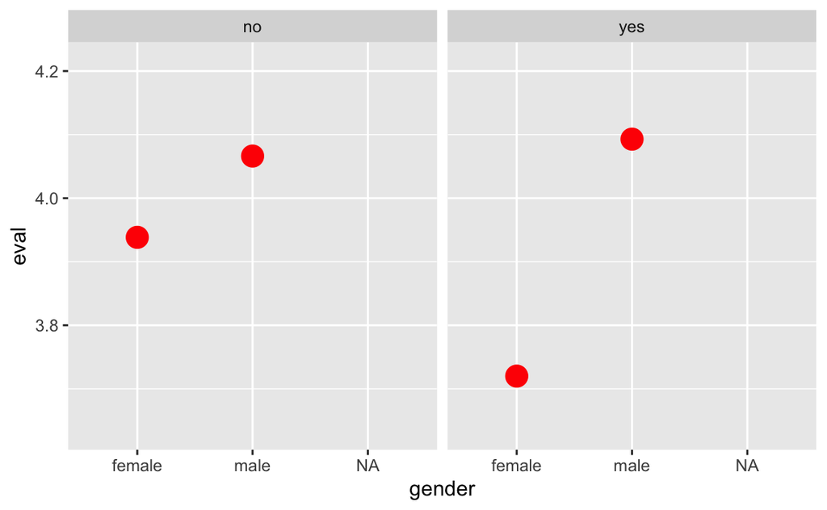

```r
gf_point(eval ~ gender | minority,
         data = TeachingRatings,
         stat = "summary",
         color = "red", size = 5)
```

## 7.4 Wann welches Diagramm?

Ein kurze Übersicht, wann sich welches Diagramm anbietet:

- Mittelwerte vergleichen – Mittelwerte (plus Rohdaten oder Streuungswerte) pro Gruppe darstellen
- Mediane vergleiche – Boxplot
- Verteilung verschiedener Gruppen darstellen – Boxplot (evtl. plus Mittelwert)
- Verteilung einer Gruppe – Dichtediagramm und/oder Histogramm bzw. Balkendiagramm
- Zusammenhang zweier metrischer Variablen – Streudiagramm
- Zusammenhänge nominaler Variablen (Häufigkeiten) – Fliesendiagramm

### 7.4.1 Zusammenhänge metrischer Variablen visualisieren

Ein Streudiagramm wird vom Befehl `gf_point()` erzeugt, z.B.:

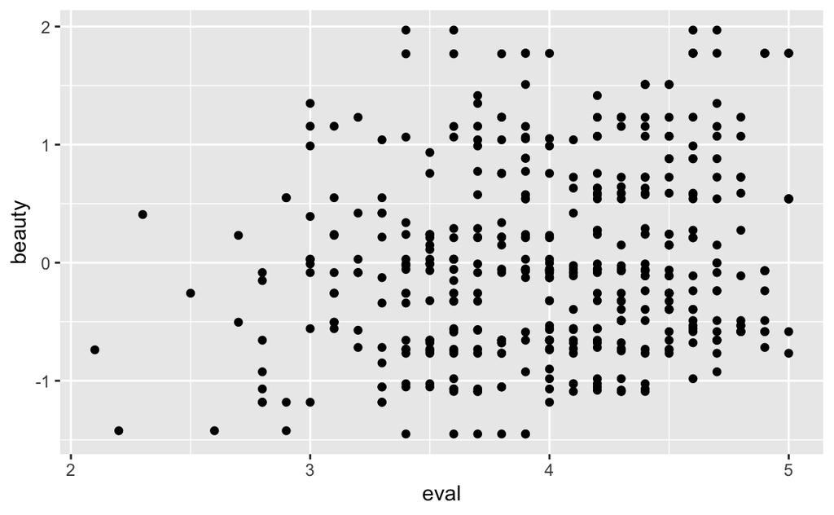

```r
gf_point(beauty ~ eval, data = TeachingRatings)
```

Wem die Komplexität nicht reicht, kann noch eine dritte (vierte?!) Variable hinzufügen. Wir können diese dritte (vierte) Variable z.B. auf die Farbe (Form) der Punkte “mappen”:

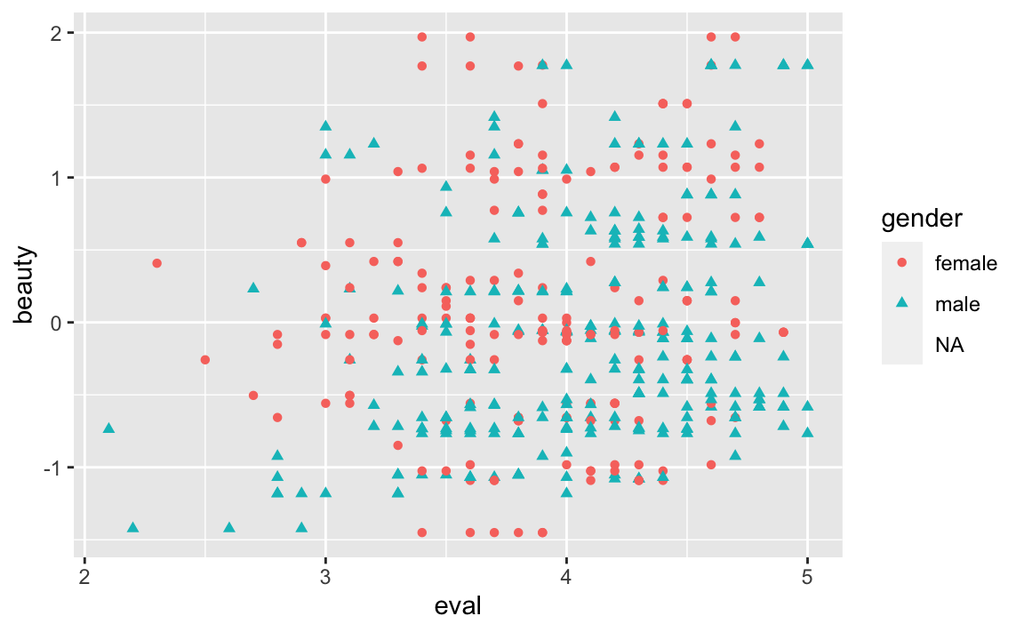

```r
gf_point(beauty ~ eval, data = TeachingRatings,
         color = ~ gender,
         shape = ~ gender)
```

Bei großen Fallzahl kann man z.B. auf zweidimensionale Dichtediagramme oder auf Kacheldiagramme zurückgreifen:

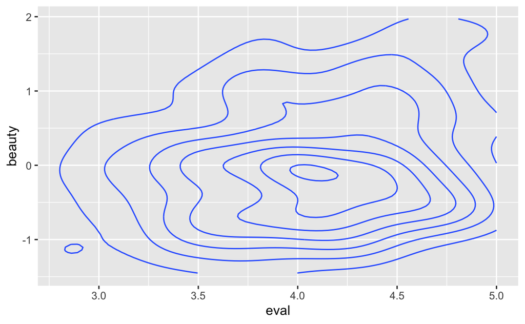

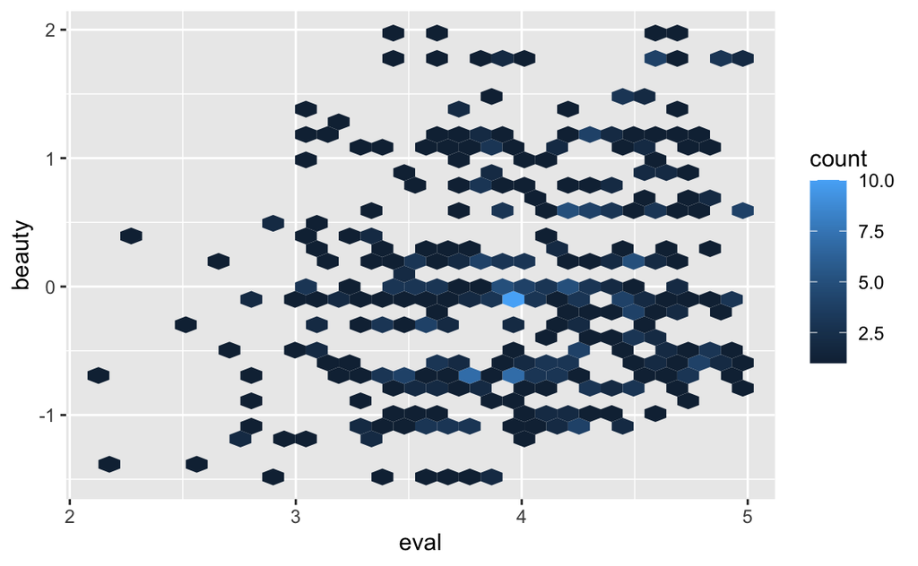

```r
gf_density2d(beauty ~ eval, data = TeachingRatings)  # 2D-Dichte
gf_hex(beauty ~ eval, data = TeachingRatings)  # Kacheldiagramm
```

### 7.4.2 Zusammenhänge nominaler Variablen visualisieren

Gibt es bei den Dozenten aus ethnischen Minderheiten mehr Männer als Frauen im Vergleich zu Nicht-Minderheiten?

Erstmal die Häufigkeiten anschauen:

```r
tally(minority ~ gender, data = TeachingRatings)
```

```
#>         gender
#> minority female male <NA>
#>      no     159  240    0
#>      yes     35   28    1
```

```r
tally(gender ~ minority, data = TeachingRatings, format = "percent")
```

```
#>         minority
#> gender      no   yes
#>   female 39.85 54.69
#>   male   60.15 43.75
#>   <NA>    0.00  1.56
```

Dann malen; zuerst schauen wir uns die Häufigkeiten pro Variable an, dann die “gemeinsamen” Häufigkeiten:

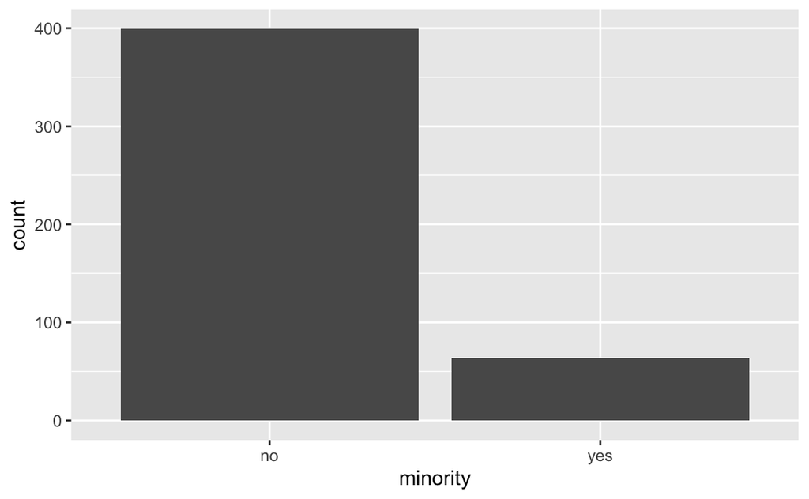

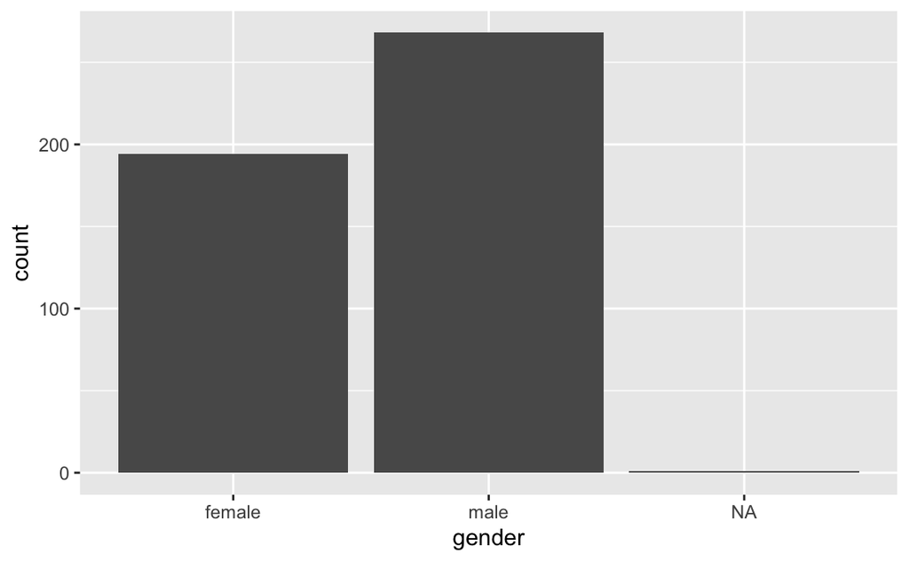

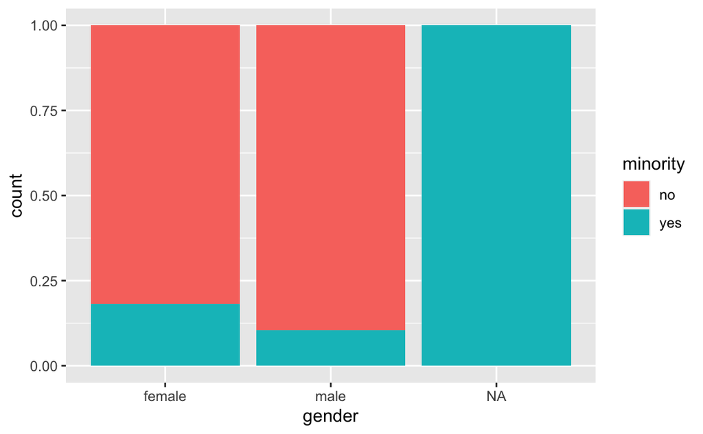

```r
gf_bar(~ minority, data = TeachingRatings)
gf_bar(~ gender, data = TeachingRatings)

gf_bar(~ gender, data = TeachingRatings, fill = ~minority, position = "fill")
```

Die “Füllstände” von Minderheiten (in Türkis) bei Frauen und Männer sind unterschiedlich, wie man in der Grafik sieht. Folglich gehen wir davon aus, dass es einen Zusammenhang gibt.

## 7.5 Die Pfeife schlägt zu

Der Parameter `stat = summary` führt dazu, dass als Punkte nicht die Rohdaten, sondern eben eine Zusammenfassung (engl. summary) dargestellt wird. In der Voreinstellung ist das der Mittelwert.

Kombinieren wir mal die Rohdaten mit den zugehörigen Mittelwerten in einen Plot:

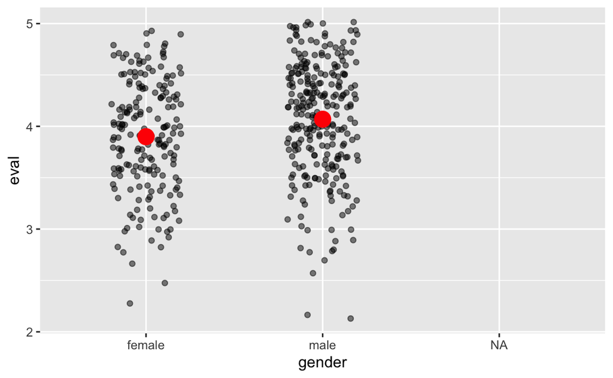

```r
gf_jitter(eval ~ gender,
          width = .2,
          alpha = .5,  # halb durchsichtig
          data = TeachingRatings) %>%
gf_point(eval ~ gender,
         data = TeachingRatings,
         stat = "summary",
         color = "red", size = 5)
```

Diese Sequenz kann grob ins Deutsche übersetzt werden mit:

```
Hey R,
Erstelle mal die Jitter-Grafik UND DANN
noch eine Punkt-Grafik für die beiden Mittelwerte (in Rot).
```

Diese Sequenz ist auch häufig praktisch:

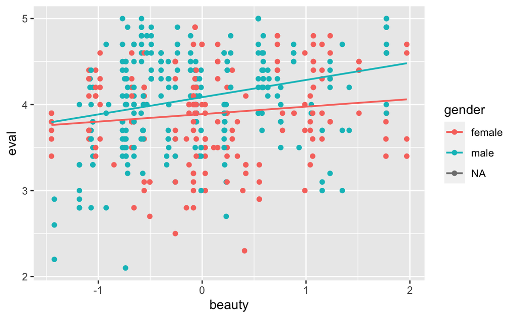

```r
gf_point(eval ~ beauty, data = TeachingRatings,
         color = ~ gender) %>%
  gf_lm()
```

## 7.6 Vertiefung: Ornamente

Hat man einiges an Fingerfertigkeit mit den Diagrammen erlangt, so erwachen Gelüste wie Achsen- oder Titelformatierung oder Farbwahl. Hier einige Hinweise dazu.

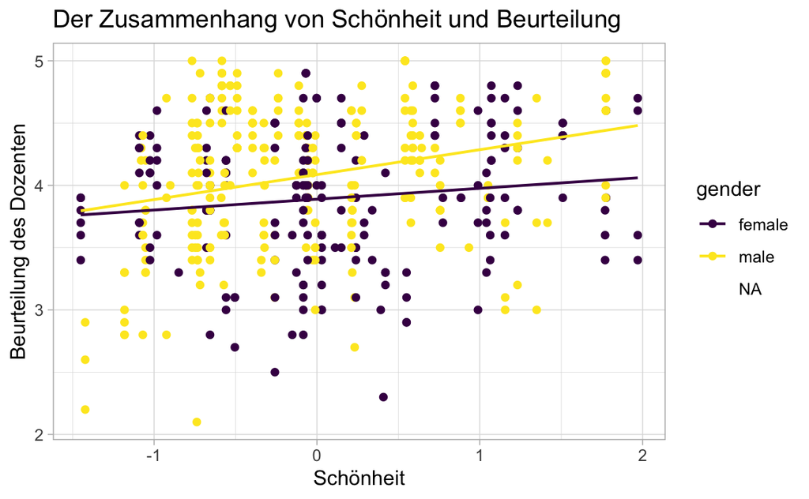

```r
gf_point(eval ~ beauty, data = TeachingRatings,
         color = ~ gender) %>%
  gf_lm() %>%
  # jetzt die Labels:
  gf_labs(x = "Schönheit",
          y = "Beurteilung des Dozenten",
          title = "Der Zusammenhang von Schönheit und Beurteilung") %>%
  # jetzt die Farbskala:
  gf_refine(scale_color_viridis_d()) %>%
  # jetzt die allgemeine Vorlage:
  gf_theme(theme_light())
```

## 7.7 Weitere Geome

[Hier](https://sebastiansauer.github.io/Praxis_der_Datenanalyse/daten-visualisieren.html#geome) finden Sie einen Überblick zu Geomen von ggplot, z.B.:

- Boxplot `gf_boxplot`
- Punkte `gf_point`
- Linien `gf_line`
- Histogramm `gf_histogram`
- …

🔖 Lesen Sie hier weiter, um Ihr Wissen zu vertiefen zu diesem Thema: [Vertiefung zur Datenvisualisierung](https://cran.r-project.org/web/packages/ggformula/vignettes/ggformula.html)

# 8 Schritt 4: Inferenzstatistik

Sagen wir, wir finden, dass die Männer in der Stichprobe im Durchschnitt 10cm größer sind als die Frauen. Ob das wohl auch für die Gesamtpopulation gilt? Oder sollten wir diesen Unterschied eher schlichtem Zufallsrauschen zuschreiben? Was ist wohl ein plausibler Schätzbereich für den wahren Größenunterschied in der Population? Mit solchen Fragen beschäftigt sich die Inferenzstatistik.

## 8.1 Der p-Wert

Ach ja, der p-Wert. Generationen von DozentenStudierenden haben sich wegen ihm oder ob ihm die Haare gerauft. Was war noch mal die Definition des p-Werts? Oder einfacher vielleicht, was will uns der p-Wert sagen?

> Der p-Wert gibt an, wie plausibel die Daten unter der getesteten Hypothese sind (der $H_0$).

Etwas präziser ausgedrückt:

> Der p-Wert gibt die Häufigkeit an, ein Ergebnis, das mindestens so extrem ist, zu bekommen, wenn man den Versuch unendlich oft unter gleichen Bedingungen wiederholen würde.

Gut am p-Wert ist, dass er ein Entscheidungsmaß bietet. Die Gefahr am p-Wert ist, dass man ihn missversteht: Der p-Wert gibt *nicht* (Sie haben richtig gelesen: *nicht*) die Wahrscheinlichkeit an, mit der die H0 gilt. Er gibt auch nicht an, wie wahrscheinlich die H1 ist. Er gibt auch nicht an, ob das Ergebnis praktisch bedeutsam ist.

## 8.2 Simulationsbasierte Inferenz

Simulationsbasierte Inferenz beruht auf einem *komputationalen Ansatz*: Man führt ein Studie unter kontrollierten Bedingungen mit Hilfe des Computers durch. “Kontrolliert” heißt dabei, dass man eine mit der $H_0$ kompatible (Daten-)Situation mittels Computer schafft, dann per Zufall auf dieser Grundlage viele Stichproben erstellt und jeweils eine Teststatistik berechnet. Schließlich vergleicht man, wie häufig der *beobachte* empirische Wert der Teststatistik in diesen nachgestellten (*simulierten*) Daten ist. Findet sich der echte empirische Wert häufig in den laut $H_0$ simulierten Daten, so haben wir Grund zur Annahme, dass die Daten mit der $H_0$ kompatibel sind – auf dieser Basis kann man sich entschließen, die $H_0$ nicht zu verwerfen. Ist der echte empirische Wert hingegen selten in den simulierten Daten, hat man Grund zu glauben, dass der echte empirische Wert *nicht* aus der Population laut $H_0$ stammt. Man verwirft dann die $H_0$.

Die simulationsbasierte Inferenz hat einige Vorteile:

- es gibt nur allgemeines Prinzip, nicht viele einzelne Verfahren
- es ist voraussetzungsarm; die Normalverteilungsannahme spielt eine geringere Rolle als bei den “klassischen” Verfahren
- das Vorgehen ist einfach und (vergleichsweise) einfach zu verstehen; das geht soweit, dass es Situationen gibt, in denen keine Formeln bekannt sind (auf denen der “klassische Ansatz” der Inferenz aufbaut), man aber mit der Simulation relativ einfach zu einem Ergebnis kommen kann.

Die Nachteile der simulationsbasierten Inferenz sind:

- Man braucht einen Computer, da die Berechnungen von Hand zu umständlich wären
- Bei sehr kleinen Stichproben ($n < 35$) sollten die “klassischen” (formelbasierten) Verfahren bevorzugt werden.
- Da der simulationsbasierte Ansatz vergleichsweise neu ist, ist er nicht so bekannt, wie der der klassische Ansatz. Es empfiehlt sich daher, die “Übersetzung” in die klassische (alte) Sprache der Inferenzstatistik zu kennen, das entsprechende Testverfahren (wie t-Test etc.) zu kennen.

### 8.2.1 Permutationstest

Im **Permutationstest** wird die Verteilung der Teststatistik unter $H_0$ simuliert (s. Abbildung 8.1), um den Zusammenhang zweier Variablen zu prüfen. D. h. laut $H_0$ gibt es gibt keinen Zusammenhang zwischen den zwei Variablen. Untersucht man z.B. ob es einen Zusammenhang im Aufbau einer Webseite (mit Bilder vs. ohne Bildern) und der Verweildauer auf der Webseite gibt, so lautet die $H_0$, dass sich die Verteilung der Verweildauer in den beiden Gruppen gleich ist.

Hier z.B. für $H_0: \pi_A-\pi_B=0$:

- Wiederhole oft (z.B. $10000 \times$):
  - Mische die $n_A+n_B$ Beobachtungen.
  - Ordne zufällig $n_A$ Beobachtungen der ersten Stichprobe zu, die restlichen der zweiten.
  - Berechne die Differenz der zwei Mittelwerte Analoges gilt für andere Teststatistiken, z.B. Anteilsdifferenzen.
- Zeichne ein Histogramm für die Differenz der 10000 Differenzwerte.
- Zähle, wie oft der beobachtete Wert der Teststatistik (oder noch extremere) in der simulierten Verteilung vorkommt.
- Der p-Wert ist der Anteil der zufälligen Teststatistiken (d.h. laut $H_0$), die mindestens so groß sind wie der beobachtete Wert.[^6]

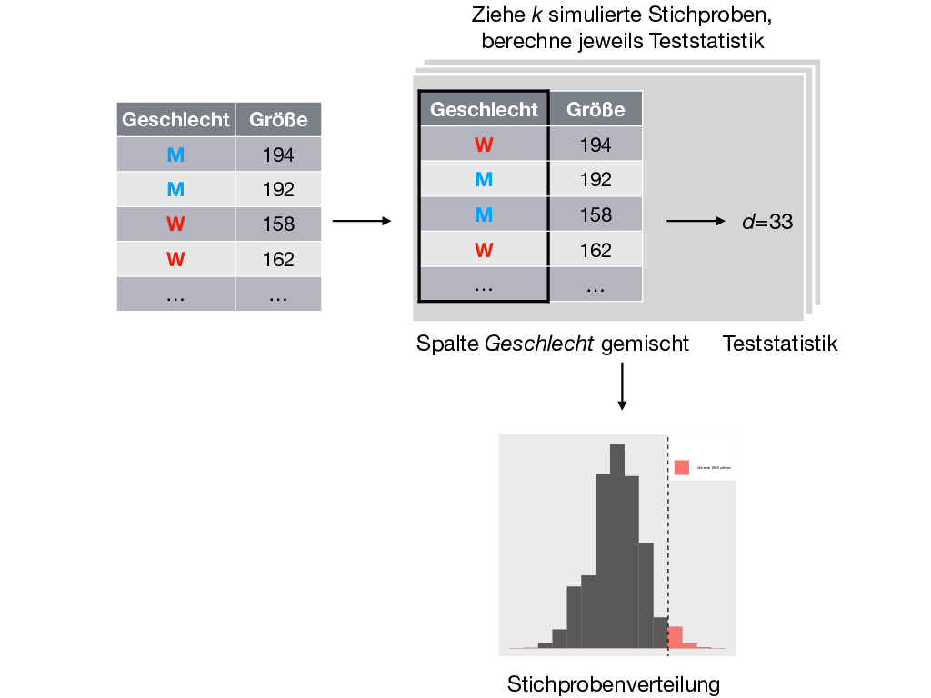

Abbildung 8.1: Sinnbild zum Permutationstest

### 8.2.2 Bootstrapping

Beim **Bootstrapping** wird die Stichprobenverteilung simuliert, z.B. um den Standardfehler $se$ oder das Konfidenzintervall zu bestimmen (s. Abbildung 8.2).

Hier z. B. für den Mittelwert:

- Wiederhole z.B. $10000 \times$
  - Ziehe mit Zurücklegen eine Stichprobe vom Umfang $n$ aus der Originalstichprobe.
  - Berechne Statistik, z. B. Mittelwert $\bar{x}$ der Bootstrap-Stichprobe. Analog für andere Statistiken, z.B. Anteil.
- Zeichne das Histogramm der Bootstrap-Verteilung der Statistik.
- Das $95\,\%$-Bootstrap-Perzentil-Intervall sind die mittleren $95\,\%$ der Bootstrap-Verteilung.

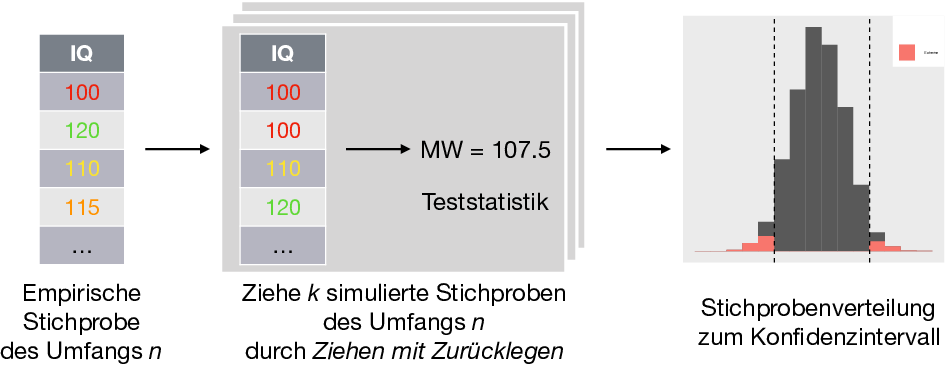

Abbildung 8.2: Sinnbild zum Bootstrap

### 8.2.3 Teststatistiken und Testverfahren

Ein Vorteil der simulationsbasierten Inferenz, dass es nur ein allgemeines Verfahren gibt (im Gegensatz zu einem “Wald” an unterschiedlichen Testverfahren). Das Prinzip der simulationsbasierten Inferenz ist praktisch immer gleich – es ändert sich nur die Teststatistik, an der man interessiert ist.

## 8.3 Auswahl klassischer Testverfahren

Eine kleine Auswahl an Testverfahren wird nachfolgend gezeigt. Diese basieren i. d. R. auf Verteilungsannahmen oder sind asymptotisch und/oder approximativ. Der zuvor gezeigte Permutationstest ist ein exakter Test.

- **Binomial-Test**: Testet den Anteil $\pi$ einer (kategorialen) Verteilung.
- **Chi-Quadrat-Unabhängigkeitstest**: Testet die Unabhängigkeit von zwei kategorialen Variablen.
- **t-Test für eine Stichprobe**: Testet den Mittelwert $\mu$ einer Normalverteilung.
- **Gepaarter t-Test**: Testet die Differenz zweier Merkmale einer Stichprobe unter der Annahme einer Normalverteilung.
- **Zweistichproben-t-Test**: Testet die Differenz der Mittelwerte zweier Stichproben unter der Annahme einer identischen Normalverteilung.
- **Varianzanalyse, ANOVA**: Testet die Gleichheit der Mittelwerte zweier oder mehr Stichproben unter der Annahme einer identischen Normalverteilung.
- **Korrelationstest**: Testet die Korrelation zweier numerischer Variablen einer Stichprobe unter der Annahme einer identischen Normalverteilung.
- **Shapiro-Wilk-Test**: Testet die Annahme einer Normalverteilung.
- **Bartlett’s Test**: Testet die Annahme von gleichen Varianzen unter der Annahme einer Normalverteilung.
- **Wilcoxon-Test**: Testet die Gleicheit von zwei Verteilungen unter der Annahme einer stetigen Verteilung gegen eine Lageverschiebung.
- **Kruskal-Wallis Test**: Testet die Gleicheit von zwei oder mehr Verteilungen unter der Annahme einer stetigen Verteilung gegen eine Lageverschiebung.

Für eine **Mindmap** der verschiedenen Verfahren siehe z. B. [hier](https://coggle.it/diagram/Vxlydu1akQFeqo6-/t/inference).

| **Y** | **X** | **Simulationsbasiert** | **Parametrisch**[^7] |
| --- | --- | --- | --- |
| kategorial - binär |  | `prop()` | `binom.test()` |
| kategorial |  | `xchisq.test()` | `xchisq.test()` |
| numerisch |  | `mean()` | `t.test()` |
| kategorial - binär | kategorial - binär | `diffprop()` | `prop.test()` |
| numerisch | kategorial - binär | `diffmean()` | `t.test()` |
| kategorial | kategorial | `xchisq.test()` | `xchisq.test()` |
| numerisch | kategorial | `aov()` | `aov()` |
| numerisch | numerisch | `cor()`, `lm()` | `cor.test()`, `lm()` |
| kategorial - binär | numerisch | `glm(family = binomial)` | `glm(family = binomial)` |

Die R-Befehle für die Testverfahren (ob simulationsbasiert oder parametrisch) folgen der normalen Syntax von mosaic:

```
verfahren(output ~ input, data = meine_daten)
```

Einige Beispiele:

```r
t.test(eval ~ gender, data = TeachingRatings)
aov(eval ~ gender + native, data = TeachingRatings)
xchisq.test(gender ~ tenure, data = TeachingRatings)
```

Manchmal ist es sinnvoll, sich das Ergebnis des Verfahrens als Objekt speichern zu lassen und sich dann mit `summary()` die zentralen Ergebnisse ausgeben zu lassen:

```r
meine_aov <- aov(eval ~ gender + native, data = TeachingRatings)
summary(meine_aov)
```

```
#>              Df Sum Sq Mean Sq F value Pr(>F)
#> gender        1    3.3    3.25   10.98 0.0010 ***
#> native        1    2.8    2.81    9.47 0.0022 **
#> Residuals   459  136.1    0.30
#> ---
#> Signif. codes:  0 '***' 0.001 '**' 0.01 '*' 0.05 '.' 0.1 ' ' 1
#> 1 observation deleted due to missingness
```

Hinweis: Um den $\chi^2$-Wert aus dem Befehl `xchisq.test()` zu extrahieren, kann man diese Syntax verwenden:

```r
library(mosaic)
chisq_wert <- xchisq.test(smoker ~ day, data = tips)$statistic
chisq_wert
```

```
#> X-squared
#>      25.8
```

## 8.4 Die Regression als Schweizer Taschenmesser

💡 Das Schweizer Taschenmesser 🔪 und den Modellierungsverfahren ist die Regressionsanalyse. Man kann sie für viele Zwecke einsetzen.

Weil die Regression so praktisch ist, hier ein Beispiel.

```r
lm(eval ~ beauty, data = TeachingRatings)
```

```
#>
#> Call:
#> lm(formula = eval ~ beauty, data = TeachingRatings)
#>
#> Coefficients:
#> (Intercept)       beauty
#>       3.998        0.133
```

`lm` heißt “lineares Modell” - weil man bei der (normalen) Regression eine Gerade in die Punktewolke der Daten legt, um den Trend zu abzuschätzen. Als nächstes gibt man die “Ziel-Variable” (Output) an, hier `eval`. Dann kommt ein Kringel `~` gefolgt von einer (mehr) Input-Variablen (Prädiktoren, UVs, hier `beauty`). Schließlich muss noch die Datentabelle erwähnt werden.

Das Ergebnis sagt uns, dass *pro Stufe von Beauty* die Variable `eval` um etwa .1 Punkte steigt. Also: Je schöner, desto “besser” sind die Dozenten auch. Immer im Schnitt, versteht sich. (Und wenn die Voraussetzungen erfüllt sind, aber darum kümmern wir uns jetzt nicht.)

Allgemein:

```
lm(output ~ input, data = meine_daten)
```

Easy, oder?

Man kann auch mehrere Prädiktoren anführen:

```r
lm(eval ~ beauty + gender, data = TeachingRatings)
```

```
#>
#> Call:
#> lm(formula = eval ~ beauty + gender, data = TeachingRatings)
#>
#> Coefficients:
#> (Intercept)       beauty   gendermale
#>       3.882        0.148        0.200
```

Möchte man ein ausführliches Ergebnis bekommen, so verlangt man von R eine Zusammenfassung (summary) des `lm`-Befehl, und zwar mit dem Befehl `summary`. Den Befehl `summary` kann man mit dem Und-danach-Befehl (`%>%`) an den `lm`-Befehl anschließen:

```r
lm(eval ~ beauty + gender, data = TeachingRatings) %>% summary()
```

```
#>
#> Call:
#> lm(formula = eval ~ beauty + gender, data = TeachingRatings)
#>
#> Residuals:
#>     Min      1Q  Median      3Q     Max
#> -1.8721 -0.3700  0.0341  0.4010  1.0322
#>
#> Coefficients:
#>             Estimate Std. Error t value Pr(>|t|)
#> (Intercept)   3.8819     0.0388  100.11  < 2e-16 ***
#> beauty        0.1484     0.0320    4.64  4.5e-06 ***
#> gendermale    0.1997     0.0511    3.91  0.00011 ***
#> ---
#> Signif. codes:  0 '***' 0.001 '**' 0.01 '*' 0.05 '.' 0.1 ' ' 1
#>
#> Residual standard error: 0.538 on 459 degrees of freedom
#>   (1 observation deleted due to missingness)
#> Multiple R-squared:  0.0667, Adjusted R-squared:  0.0626
#> F-statistic: 16.4 on 2 and 459 DF,  p-value: 1.32e-07
```

Dazu werden die durch `+` getrennt. Pro Prädiktor wird die Steigung der Regressionsgeraden angegeben. Man kann auch nominale Prädiktoren reinfüttern. Das macht die Regression so praktisch.

### 8.4.1 Interaktionseffekte (Moderatoranalysen)

Aber es könnte es nicht sein, dass Schönheit bei Männern *wichtiger* ist als bei Frauen? Das würde bedeuten, dass jedes bisschen (=jeder Punkt) Schönheit zu *mehr* Punkten in der Bewertung führt. Es ist also denkbar, dass die Steigung der Regressionsgeraden bei Männern steiler ist als bei Frauen.

> *Wenn* die Geraden also unterschiedlich steil sind (nicht parallel, mit anderen Worten), so liegt ein Interaktionseffekt vor; ansonsten nicht.

Kann man nicht eine Regressionsgerade für Männer und eine für Frauen bekommen. Ja, das geht. Aber schauen wir uns vielleicht erstmal ein Bildchen dazu an, das macht die Sache klarer:

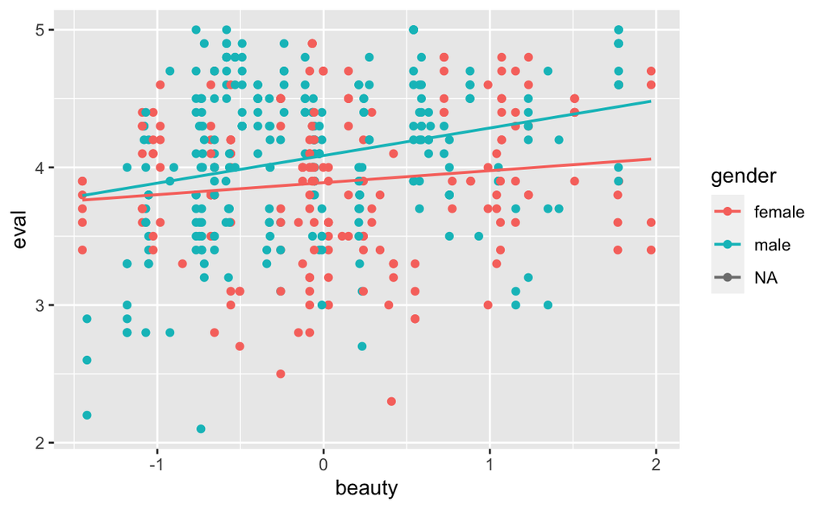

```r
gf_point(eval ~ beauty,
         data = TeachingRatings,
         color = ~gender) %>%
  gf_lm()
```

Mit `gf_lm` bekommen wir eine Anpassungslinie, die mit dem `lm`-Befehl (also der normalen Regression) im Hintergrund durch erstellt wird, und zwar pro Stufe von Geschlecht (d.h. eine für Frauen und eine für Männer).

Achtung, das ist wichtig: Wenn die beiden Geraden parallel sind, dann gibt es keinen Interaktionseffekt. Hier sind die Geraden augenscheinlich nicht parallel, also liegt ein Interaktionseffekt in den Daten vor.

Um den `lm`-Befehl zu überzeugen, einen Interaktionseffekt zwischen Geschlecht (gender) und Schönheit (beauty) zu berechnen, schreibt man in den `lm`-Befehl: `+ gender:beauty`:

```r
lm(eval ~ beauty + gender + gender:beauty, data = TeachingRatings) %>%
  summary()
```

```
#>
#> Call:
#> lm(formula = eval ~ beauty + gender + gender:beauty, data = TeachingRatings)
#>
#> Residuals:
#>     Min      1Q  Median      3Q     Max
#> -1.8382 -0.3746  0.0415  0.3999  1.0676
#>
#> Coefficients:
#>                   Estimate Std. Error t value Pr(>|t|)
#> (Intercept)         3.8889     0.0389  100.00  < 2e-16 ***
#> beauty              0.0871     0.0471    1.85  0.06504 .
#> gendermale          0.1970     0.0510    3.86  0.00013 ***
#> beauty:gendermale   0.1132     0.0640    1.77  0.07773 .
#> ---
#> Signif. codes:  0 '***' 0.001 '**' 0.01 '*' 0.05 '.' 0.1 ' ' 1
#>
#> Residual standard error: 0.536 on 458 degrees of freedom
#>   (1 observation deleted due to missingness)
#> Multiple R-squared:  0.073,  Adjusted R-squared:  0.0669
#> F-statistic:   12 on 3 and 458 DF,  p-value: 1.37e-07
```

### 8.4.2 Vorhersagen

Man kann die Regression nutzen, um Vorhersagen zu treffen. Sagen wir, der neue Dozent ist umwerfend hübsch (1.5); wie gut wird er wohl (im Schnitt) beurteilt werden?

Als Vorbereitung speichern wir unser Regressionsmodell in einer eigenen Variablen:

```r
mein_lm <- lm(eval ~ beauty, data = TeachingRatings)
```

Dazu nimmt man am besten den Befehl `predict`, weil wir wollen eine Vorhersage treffen:

```r
predict(mein_lm, data.frame(beauty = 1.5))
```

```
#>   1
#> 4.2
```

Aha. Er würde im Schnitt mit 4.2 (auf einer Skala von 1 bis 5) bewertet werden. Tja, Schönheit zahlt sich offenbar vielfältig aus.

### 8.4.3 Modellgüte

Wie “gut” ist das Modell? Präziser gesagt: Wie genau sagt das Modell die Beurteilung der Dozenten vorher? Eine Antwort darauf gibt $R^2$: Je größer $R^2$, desto besser die Vorhersage. Noch genauer: Wenn man für jeden Dozenten den Mittelwert der Beurteilung als ihr oder seinen Wert vorhersagen würde: Wie groß wäre dann der mittlere Vorhersagefehler? Nennen wir das den Fehler der “Nullmodells” (weil keine/null Prädiktoren). Nun berechnen wir den mittleren Vorhersagefehler in unserem Modell. Dann setzen wir beide Werte in ein Verhältnis: voilà, hier steht $R^2$ vor Ihnen.

Eine zweite Möglichkeit bestünde darin, nur den mittleren Vorhersagefehler unseres Modells zu berichten, man spricht dann auch vom *Mean Squared Error* (MSE) oder dessen Wurzel *Root Mean Squared Error* (RMSE). Der RMSE gibt grob gesagt an, um wie viel unsere Vorhersage im Schnitt daneben liegt. Er berechnet so so:

1. Man nehme die Vorhersagefehler unserer Regression
2. Quadriere sie jeweils
3. Addiere sie dann auf
4. Bilde den Mittelwert dieser Werte
5. Ziehe die Wurzel

Auf Errisch:

```r
vohersagefehler <- residuals(mein_lm)

RMSE <- sqrt(mean(vohersagefehler^2))
RMSE
```

```
#> [1] 0.545
```

## 8.5 Effektstärkemaße

Der p-Wert ist ein Maß für die Plausibilität einer Hypothese; er ist kein Maß für die Stärke eines Effekts. Grund dafür ist u.a., dass die Stichprobengröße in die Berechnung des p-Werts einfließt. Große Stichproben werden daher (unter sonst gleichen Umständen) schneller signifikant als kleine Stichproben (und sehr große viel schneller…).

Um die Stärke von Effekten zu bemessen, gibt man den Wert der Teststatistik an (oder eine aus ihr abgeleitete Größe); diese bezeichnet man als *Effektstärkemaße*. Vergleicht man z.B. zwei Mittelwerte ist diese Mittelwertsdifferenz die Effektstärke; teilt man diesen Wert noch durch die mittlere Standardabweichung, so erhält man eine häufig verwendete Kenngröße, Cohens d. Berechnen wir Cohens d für den Mittelwertsunterschied der Beurteilung abhängig vom Geschlecht:

```r
library(lsr)
cohensD(eval ~ gender, data = TeachingRatings)
```

```
#> [1] 0.309
```

Bei einer Varianzanalyse ist das Verhältnis von erklärter zu nicht erklärter Varianz oder zu Gesamtvarianz die typische Effektgröße. Diese Kenngröße wird als $\eta^2$ (Eta-Quadrat) bezeichnet oder auch als $R^2$. Ebenfalls im Paket `lsr` gibt es einen Befehl für diese Effektgröße:

```r
meine_aov <- aov(eval ~ gender, data = TeachingRatings)

etaSquared(meine_aov)
```

```
#>        eta.sq eta.sq.part
#> gender 0.0229      0.0229
```

Effektstärken für Anteilsdifferenzen werden am besten als Anteilsdifferenzen wiedergegeben, z.B. im Rahmen von $\chi^2$-Tests. Bei $\chi^2$-Tests, bei denen mindestens eine der Variablen mehr als zwei Stufen aufweist, kann auf Cramers V ausgewichen werden:

```r
cramersV(TeachingRatings$native, TeachingRatings$tenure)
```

```
#> [1] 0.124
```

Bei einer Korrelationsanalyse ist die Sache einfach: Der (absolute) Wert von $r$ ist das Effektstärkemaß.

# 9 Schritt 5: Kommunizieren

Kommunizieren meint hier, dass Sie Ihre Ergebnisse anderen mitteilen - als Student heißt das häufig in Form einer Seminararbeit an den Dozenten.

Einige Hinweise:

- Die wesentlichen Ergebnisse kommen in den Hauptteil der Arbeit. Interessante Details in den Anhang.
- Der Mensch ist ein Augentier. Ihr Gutachter auch. Achten Sie auf optisch ansprechende Darstellung; schöne Diagramme helfen.
- Dozenten achten gerne auf formale Korrektheit. Das Gute ist, dass dies relativ einfach sicherzustellen ist, da auf starren Regeln basierend.

## 9.1 Tabellen und Diagramme

Daten kommunizieren heißt praktisch zumeist, Tabellen oder Diagramme zu erstellen. Meist gibt es dazu Richtlinien von Seiten irgendeiner (selbsternannten) Autorität wie Dozenten oder Fachgesellschaften. Zum Beispiel hat die [APA](http://www.apa.org) ein umfangreiches Manual zum Thema Manuskriptgestaltung publiziert; die deutsche Fachgesellschaft der Psychologie entsprechend. Recherchieren Sie mal, wie in Ihren Richtlinien Tabellen und Diagramme zu erstellen sind (oder fragen Sie Ihren Gutachter). Es gibt einige R-Pakete, die helfen, Tabellen zu erstellen, etwa [apaTables](https://cran.r-project.org/web/packages/apaTables/vignettes/apaTables.html), [sjPlot](http://www.strengejacke.de/sjPlot/articles/sjtlm.html), [xtable](https://cran.r-project.org/web/packages/xtable/vignettes/xtableGallery.pdf) oder [kableExtra](https://cran.r-project.org/web/packages/kableExtra/vignettes/awesome_table_in_html.html).

## 9.2 Für Fortgeschrittene: RMarkdown

Wäre das nicht cool: Jegliches Formatieren wird automatisch übernommen und sogar so, das es schick aussieht? Außerdem wird Ihr R-Code und dessen Ergebnisse (Tabellen und Diagramme oder reine Zahlen) automatisch in Ihr Dokument übernommen. Keine Copy-Paste-Fehler mehr. Keine händisches Aktualisieren, weil Sie Daten oder die vorhergehende Analyse geändert haben. Hört sich gut an? Ist es auch. Probieren Sie mal [RMarkdown](http://rmarkdown.rstudio.com) aus.

Sauer, S. (2019). *Moderne Datenanalyse mit R*. Wiesbaden, Germany: Springer. doi:10.1007/978-3-658-21587-3

[^1]: oder alternativ: https://sebastiansauer.github.io/data/TeachingRatings.csv
[^2]: Natürlich muss dieses Paket vorab einmalig installiert und nach jedem Start von R mit `library(tidyverse)` gestartet werden.
[^3]: Tabellen in R bezeichnet man als *Dataframe*.
[^4]: Alternativ würde z.B. auch dieser R-Code helfen: `TeachingRatings$Traumdozent <- TeachingRatings$beauty > 1`.
[^5]: Probieren Sie mal die "verwackelte Variante: `gf_jitter(eval ~ gender, data = TeachingRatings)`. Durch das Verwackeln liegen die Punkte nicht mehr aufeinander und man erkennt besser, was Sache ist.
[^6]: Bei ungerichteten, zweiseitigen Tests z.B. das Doppelte des einseitigen Tests. Bei symmetrischen Verteilungen auch Absolutbetrag.
[^7]: Verteilungsannahmen!